# intelligent_systems_examination_notebook

```python
# CODE_CELL01
import time
import sys
import subprocess
import pkg_resources

# Profile import times
start_total = time.time()
start = time.time()
import sys
print(f"sys import time: {time.time() - start:.3f}s")
start = time.time()
import subprocess
print(f"subprocess import time: {time.time() - start:.3f}s")
start = time.time()
import pkg_resources
print(f"pkg_resources import time: {time.time() - start:.3f}s")

# Profile conda environment query
start = time.time()
try:
    env_name = subprocess.check_output(['conda', 'info', '--envs']).decode()
    print(f"Conda env query time: {time.time() - start:.3f}s")
except Exception as e:
    print(f"Conda env query failed: {e}")

print("Current environment details:")
print(f"Python executable: {sys.executable}")

# Profile package check
start = time.time()
required_packages = ['pandas', 'numpy', 'scikit-learn', 'nltk', 'keras', 'tensorflow', 'matplotlib', 'seaborn', 'wordcloud']
installed_packages = [pkg.project_name.lower() for pkg in pkg_resources.working_set]
print(f"Package check time: {time.time() - start:.3f}s")

print("\nPackage verification:")
for package in required_packages:
    if package in installed_packages:
        print(f"✓ {package} - installed")
    else:
        print(f"✗ {package} - NOT installed")

print(f"Total cell execution time: {time.time() - start_total:.3f}s")
```

```
C:\Users\3C Tech\AppData\Local\Temp\ipykernel_27092\63401341.py:5: DeprecationWarning: pkg_resources is deprecated as an API. See https://setuptools.pypa.io/en/latest/pkg_resources.html
  import pkg_resources
```

```
sys import time: 0.000s
subprocess import time: 0.000s
pkg_resources import time: 0.000s
Conda env query failed: [WinError 2] The system cannot find the file specified
Current environment details:
Python executable: C:\Users\3C Tech\.conda\envs\FirstEnv\python.exe
Package check time: 0.000s

Package verification:
✓ pandas - installed
✓ numpy - installed
✓ scikit-learn - installed
✓ nltk - installed
✓ keras - installed
✓ tensorflow - installed
✓ matplotlib - installed
✓ seaborn - installed
✓ wordcloud - installed
Total cell execution time: 0.058s
```

1. Fairness and Justice
- The AI system must treat every job applicants equally. It should not make decisions based on a person's gender, race, age or religion. It should only look at their skills and qualifications for the job.
- Imagine the AI was trained using the company's hiring data from the last 20 years. If the company mostly hired men in the past, the AI might learn this unfair patterns. As a result, it could automatically give lower scores to female applicants, even if they are the best candidates for the job.
2. Accountability and Responsibility
- If the AI makes a mistake or a bad decision, there must be a person or a team who is responsible for it. A company cannot just say, "The computer did it".
- The AI system wrongly rejects a perfect candidate because of a glitch. The candidate complains to the company. Instead of fixing the problem, the company managers blame the AI and say they can not do anything about it. No one takes the responsibility for the mistake.
3. Transparency and Explainability
- The AI's decisions should not be a complete secret. It should be possible to understand why the AI made certain choice. The system should be clear, not a "black box".
- An applicant asks the company why they wer not selected for an interview. The HR manager replies, "Sorry we do not know the exact reason. The AI system made the decision." This is not transparent because the applicant gets no useful feedback.
4. Emerging Frameworks
- This is about following new rules and ideas to make sure AI is safe and respects people. Thus includes protecting a person's private information (data privacy) and always having a human check the AI's final decisions. The AI system secretly finds an applicant's private social media accounts. It then uses their personal photos and posts to judge their character, and decides not to hire them based on that information. This is a violation of the applicant's privacy

```python
# CODE_CELL02
import pandas as pd
import numpy as np

# Sample hiring data
np.random.seed(42)
data = {
    'applicant_id': range(1000),
    'education_level': np.random.choice(['High School', 'Bachelor', 'Master', 'PhD'], 1000, p=[0.3, 0.4, 0.25, 0.05]),
    'years_experience': np.random.randint(0, 20, 1000),
    'gender': np.random.choice(['Male', 'Female', 'Other'], 1000, p=[0.6, 0.35, 0.05]),
    'age': np.random.randint(22, 65, 1000),
    'previous_salary': np.random.normal(50000, 20000, 1000),
    'hired': np.random.choice([0, 1], 1000, p=[0.7, 0.3])
}
df = pd.DataFrame(data)
df.to_csv("hiring_data.csv", index=False)
```

```
import pandas as pd
import numpy as np
from scipy.stats import chi2_contingency, ttest_ind, pearsonr
import matplotlib.pyplot as plt
import seaborn as sns

def show_distribution(column):
    """Show the distribution of a categorical column."""
    counts = df[column].value_counts(normalize=True) * 100
    print(f"Distribution of {column}:")
    print(counts.round(2))
    counts.plot(kind='bar', title=f"Distribution of {column}")
    plt.show()

def compare_groups(column, target="hired"):
    """Compare hiring rates across groups for a categorical variable."""
    rates = df.groupby(column)[target].mean()
    print(f"Hiring rates by {column}:")
    print(rates.round(2))
    rates.plot(kind='bar', title=f"Hiring rates by {column}")
    plt.show()

def plot_histogram(column):
    """Plot histogram of a numerical variable."""
    plt.hist(df[column], bins=20, edgecolor="black")
    plt.title(f"Histogram of {column}")
    plt.xlabel(column)
    plt.ylabel("Frequency")
    plt.show()

def chi_square_test(feature, outcome="hired"):
    """Chi-square test for independence between two categorical variables."""
    contingency = pd.crosstab(df[feature], df[outcome])
    chi2, p, dof, expected = chi2_contingency(contingency)
    print(f"Chi-square test between {feature} and {outcome}")
    print(f"Chi2 statistic = {chi2:.2f}, p-value = {p:.4f}")
    return p

def t_test_groups(feature, outcome="hired"):
    """T-test for comparing means of a numerical feature between hired vs not hired."""
    group1 = df[df[outcome] == 1][feature]
    group0 = df[df[outcome] == 0][feature]
    t_stat, p = ttest_ind(group1, group0, equal_var=False)
    print(f"T-test for {feature} by {outcome}")
    print(f"T-statistic = {t_stat:.2f}, p-value = {p:.4f}")
    return p

def correlation_check(feature, outcome="hired"):
    """Pearson correlation between a numerical feature and hiring outcome."""
    corr, p = pearsonr(df[feature], df[outcome])
    print(f"Correlation between {feature} and {outcome}")
    print(f"Correlation = {corr:.2f}, p-value = {p:.4f}")
    return corr, p
```

```
For categorical attributes bias detection
Hiring rates by gender:
gender
Female    0.26
Male      0.31
Other     0.23
Name: hired, dtype: float64
```

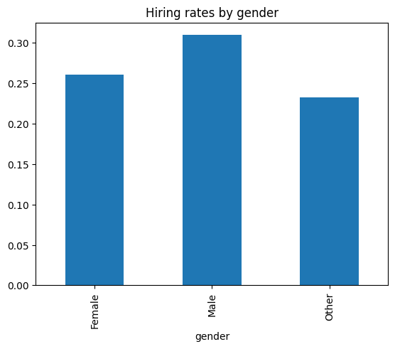

```
Hiring rates by education_level:
education_level
Bachelor       0.29
High School    0.30
Master         0.28
PhD            0.17
Name: hired, dtype: float64
```

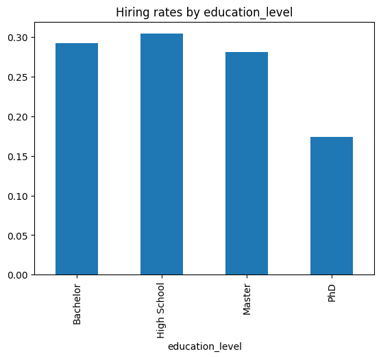

```
For numerical attributes bias detection
```

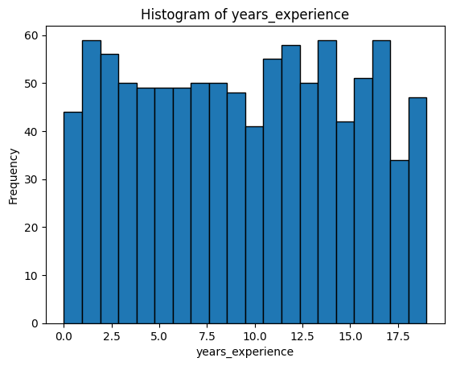

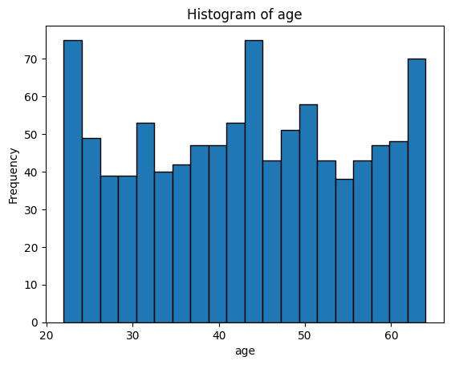

```python
# CODE_CELL03
import pandas as pd
import numpy as np
from scipy.stats import chi2_contingency, ttest_ind, pearsonr
import matplotlib.pyplot as plt
import seaborn as sns

#for categorical data bias detection
def compare_groups(column, target="hired"):
    # Compare hiring rates across groups for a categorical variable.
    rates = df.groupby(column)[target].mean()
    print(f"Hiring rates by {column}:")
    print(rates.round(2))
    rates.plot(kind='bar', title=f"Hiring rates by {column}")
    plt.show()

#for numerical data bias detection
def plot_histogram(column):
    #Plot histogram of a numerical variable."""
    plt.hist(df[column], bins=20, edgecolor="black")
    plt.title(f"Histogram of {column}")
    plt.xlabel(column)
    plt.ylabel("Frequency")
    plt.show()

print("For categorical attributes bias detection")
compare_groups('gender')
compare_groups('education_level')

print("For numerical attributes bias detection")
plot_histogram('years_experience')
plot_histogram('age')
```

1. ස්ත්‍රී/පුරුෂ භාවය අනුව බඳවා ගැනීමේ අනුපාත (gender) Female: 0.26 (එනම්, කාන්තා අයදුම්කරුවන්ගෙන් **26%**ක් බඳවාගෙන ඇත)

Male: 0.31 (එනම්, පිරිමි අයදුම්කරුවන්ගෙන් **31%**ක් බඳවාගෙන ඇත)

Other: 0.23 (එනම්, වෙනත් ලෙස හඳුනාගත් අයදුම්කරුවන්ගෙන් **23%**ක් බඳවාගෙන ඇත)

නිගමනය (Gender): මෙහි යම් පරතරයක් පවතී. පිරිමි අයදුම්කරුවන් බඳවා ගැනීමේ අනුපාතය, කාන්තා අයදුම්කරුවන්ට වඩා 5%කින් වැඩිය (31% - 26% = 5%). "වෙනත්" කාණ්ඩයේ අනුපාතය අඩුම වුවත්, එම කණ්ඩායමේ අයදුම්කරුවන් සංඛ්‍යාව අඩු විය හැකිය (මෙය show_distribution මගින් තහවුරු කරගත හැක).

5%ක වෙනස සැලකිය යුතුද නැද්ද යන්න තීරණය කිරීමට ඊළඟ පියවරේදී කරන Chi-Square පරීක්ෂණය වැදගත් වේ. නමුත්, මෙම වෙනස සුළු පක්ෂග්‍රාහී දර්ශකයක් (minor bias indicator) ලෙස සැලකිය හැක.

2. අධ්‍යාපන මට්ටම අනුව බඳවා ගැනීමේ අනුපාත (education_level) Bachelor: 0.29 (උපාධිධාරීන්ගෙන් **29%**ක් බඳවාගෙන ඇත)

High School: 0.30 (උසස් පෙළ මට්ටමෙන් **30%**ක් බඳවාගෙන ඇත)

Master: 0.28 (පශ්චාත් උපාධිධාරීන්ගෙන් **28%**ක් බඳවාගෙන ඇත)

PhD: 0.17 (ආචාර්ය උපාධිධාරීන්ගෙන් **17%**ක් පමණක් බඳවාගෙන ඇත)

1. gender (p=0.1803) Higher than 0.05
- This means this result is not statistically significant. Although we saw small differences in the hiring rates between men (31%) and women (26%), this p-value tells us there is an 18% probability that this differences is purely due to random chance.
- There is no strong statistical evidence to suggest that the company is biased against any gender in its hiring process.
2. education_level (p=0.3312) higher than 0.05
- This result is also not statistically significant. It indicates that any variations in hiring rates among candidates with different educational backgrounds (e.g., Bachelor's vs. Master's) are very likely random. There is a 33% probability that these differences are just a coincidence.
- There is no strong statistical evidence to suggest that the company's hiring process is biased based on a candidate's level of education.

t_test සහ correlation පාවිච්චි කරන්නේ numbers එක්ක වැඩ කරනකොට (numerical data).

මෙතන අපිට බලන්න ඕන 'gender' (වර්ගයක් - categorical) සහ 'hired' (වර්ගයක් - 0 හෝ 1, categorical) අතර සම්බන්ධයක් තියෙනවද කියලයි.

වර්ග දෙකක් (two categorical variables) අතර සම්බන්ධයක් තියෙනවද කියලා බලන්න පාවිච්චි කරන standard test එක තමයි Chi-Square Test එක.

```python
# CODE_CELL04
def chi_square_test(feature, outcome="hired"):
    #Chi-square test for independence between two categorical variables.
    contingency = pd.crosstab(df[feature], df[outcome])
    chi2, p, dof, expected = chi2_contingency(contingency)
    print(f"Chi-square test between {feature} and {outcome}")
    print(f"Chi2 statistic = {chi2:.2f}, p-value = {p:.4f}")
    return p
chi_square_test('gender', 'hired')
chi_square_test('education_level', 'hired')
```

```
Chi-square test between gender and hired
Chi2 statistic = 3.43, p-value = 0.1803
Chi-square test between education_level and hired
Chi2 statistic = 3.42, p-value = 0.3312
```

```
np.float64(0.33119064323533237)
```

MARKDOWN_CELL01

The Chi-square test is the correct tool for this task because we are comparing 2 categorical variables.

- gender -> Male, Female, Other
- hired -> Hired or Not Hired (1,0)

This test has done to identify that there is a real, statistical relationship between these attributes.

In the results section we can see that there is a value called p-value. p-value is a score that shows the probability of our results being just a random coincidence.The standard cutoff value for this value is 0.05.

In our results p-value = 0.1803 -> much higher than 0.05. So this means that the diferences in hiring rates between genders are very likely due to random chance and not because of an underlying bias.

In simple terms: Based on this data, **we did not find any statistical proof of gender bias** in the hiring process.

MARKDOWN_CELL02

Long-term societal implications of widespread AI hiring systems

Using AI systems in hiring can change how people get jobs in the future. There are some good effects and also some risks.

On the positive side, AI can help companies save time by quickly checking thousands of job applications. It can also reduce some human bias, making the process more fair if it is designed well. AI can help employers find the best candidates based on skills and qualifications, instead of personal opinions.

However, there are also long-term concerns. AI learns from past data, and if that data contains unfair patterns—like gender or race bias—it can repeat those same mistakes. This could make it harder for some groups of people to get jobs. Another problem is that AI cannot easily understand human qualities like creativity, communication, or emotion. As a result, some good candidates might be rejected unfairly.

There is also the issue of transparency. Many AI systems are not clear about how they make decisions, so applicants may not know why they were rejected. This could reduce trust between people and companies. Also, if hiring becomes too automated, human resource professionals may lose their jobs, and the process may feel less personal.

In the long run, society needs to balance technology and fairness. To make AI hiring helpful, it should be regularly checked for bias, be transparent, and include human judgment when needed.

MARKDOWN_CELL03

Stakeholder responsibilities and accountability measures

Everyone involved in AI hiring systems has an important role to play. Employers, developers, policymakers, and even job applicants have responsibilities.

Employers should make sure the AI systems they use are fair and tested for bias. They should be open with candidates about how AI is used in the hiring process. Developers need to build AI tools that are accurate, fair, and explainable. They must also use data that represents all kinds of people.

Policymakers (governments and regulators) should create clear rules to make sure companies use AI responsibly. This can include regular audits, fairness checks, and reporting requirements. Job applicants should also have the right to ask for a human review if they are rejected by an automated system.

To make AI hiring systems trustworthy, there should be regular evaluations, clear records of how AI decisions are made, and cooperation between all stakeholders. Together, they can make AI hiring more fair, transparent, and responsible for everyone.

```python
# CODE_CELL05

feedback_data = [
    "The delivery was TERRIBLE!!! My order #12345 arrived 3 days late. I'm so disappointed with the seller.",
    "Great product! Really happy with my purchase from this particular seller. Order #67890 was perfect.",
    "J'adore ce vendeur! Mon colis #55667 est arrivé plus tôt que prévu et en parfait état.",
    "Customer service at eBay was unhelpful. My iPhone 14 Pro has issues. I cannot believe they won't help me.",
    "මගේ order #99887 හි පැකේජ් එක හොඳින් පැමිණියේ නෑ. දේවල් කිහිපයක් අඩුයි.",
    "LOVE this new MacBook Pro!!! Order delivered to 123 Main St on time. 5 stars!",
    "Die Lieferung war viel zu spät. Bestellung #77889 kam nach zwei Wochen an. Sehr enttäuschend.",
    "The USB cable I ordered was damaged. Never ordering again!",
    "எனது order #44556 நேரத்தில் கிடைத்தது. பொருளின் தரம் மிகச் சிறந்தது. நன்றி!",
    "My name is Leann, I ordered a new laptop from seller BestTech on 05/10/2023. The laptop is fantastic!",
    "我对这次购物非常不满意。订单 #66778 延迟了五天才送到。",
    "I received my order #54321, but the package was opened and some items were missing. Very unhappy with the service.",
    "الخدمة سيئة للغاية! طلبي #22445 لم يصل حتى الآن. أريد استرداد المبلغ فوراً.",
    "The headphones I bought are amazing! Thanks to the seller AudioWorld. Order #98765",
    "मेरा ऑर्डर #33990 समय पर आ गया और पैकिंग भी बहुत अच्छी थी। धन्यवाद!",
    "Worst experience ever! My order #11223 was lost in transit. I want a refund immediately. I'm Sandrie",
    "注文 #11298 は予定通り届きました。商品の品質にもとても満足しています。"
    "El producto llegó roto y la caja estaba dañada. Pedido #33445. Muy mala experiencia.",
]
```

MARKDOWN_CELL04

```
import re
import spacy
from langdetect import detect

# Load small English NLP model (for NER)
nlp = spacy.load("en_core_web_sm")

# ---------- Cleaning Functions ----------
def basic_clean(text_list):
    """Lowercase text and remove punctuation."""
    cleaned = [re.sub(r'[^\w\s]', '', t.lower()) for t in text_list]
    return cleaned

def remove_stopwords(text_list):
    """Remove common English stopwords."""
    from spacy.lang.en.stop_words import STOP_WORDS
    cleaned = []
    for t in text_list:
        tokens = [word for word in t.split() if word not in STOP_WORDS]
        cleaned.append(" ".join(tokens))
    return cleaned

def normalize_text(text_list):
    """Handle punctuation, case, and whitespace consistently."""
    cleaned = [re.sub(r'\s+', ' ', re.sub(r'[^\w\s]', '', t)).strip().lower() for t in text_list]
    return cleaned

# ---------- Entity Extraction ----------
def extract_entities_spacy(text_list):
    """Extract named entities (organizations, products, locations, order numbers)."""
    entities = []
    for t in text_list:
        doc = nlp(t)
        entities.append([(ent.text, ent.label_) for ent in doc.ents])
    return entities

def extract_numbers(text_list):
    """Extract numeric values (e.g., order IDs, numbers)."""
    numbers = []
    for t in text_list:
        nums = re.findall(r'\d+', t)
        numbers.append(nums)
    return numbers

def keyword_match(text_list, keywords):
    """Find keyword matches in text."""
    matches = []
    for t in text_list:
        found = [kw for kw in keywords if kw.lower() in t.lower()]
        matches.append(found)
    return matches

# ---------- Language Detection ----------
def detect_language_langdetect(text_list):
    """Detect the language of each text."""
    return [detect(t) for t in text_list]

def count_words(text_list):
    """Count words in each feedback."""
    return [len(t.split()) for t in text_list]

def char_length(text_list):
    """Return character length of each feedback."""
    return [len(t) for t in text_list]
```

```python
# CODE_CELL05
import re
import spacy
from langdetect import detect

# Load small English NLP model (for NER)
nlp = spacy.load("en_core_web_sm")

def normalize_text(text_list):
    #Handle punctuation, case, and whitespace consistently.
    cleaned = [re.sub(r'\s+', ' ', re.sub(r'[^\w\s]', '', t)).strip().lower() for t in text_list]
    return cleaned

cleaned_feedback = normalize_text(feedback_data)

print("Cleaned Feedback")
for text in cleaned_feedback:
    print(text)
```

```
Cleaned Feedback
the delivery was terrible my order 12345 arrived 3 days late im so disappointed with the seller
great product really happy with my purchase from this particular seller order 67890 was perfect
jadore ce vendeur mon colis 55667 est arrivé plus tôt que prévu et en parfait état
customer service at ebay was unhelpful my iphone 14 pro has issues i cannot believe they wont help me
මග order 99887 හ පකජ එක හඳන පමණය න දවල කහපයක අඩය
love this new macbook pro order delivered to 123 main st on time 5 stars
die lieferung war viel zu spät bestellung 77889 kam nach zwei wochen an sehr enttäuschend
the usb cable i ordered was damaged never ordering again
எனத order 44556 நரததல கடததத பரளன தரம மகச சறநதத நனற
my name is leann i ordered a new laptop from seller besttech on 05102023 the laptop is fantastic
我对这次购物非常不满意订单 66778 延迟了五天才送到
i received my order 54321 but the package was opened and some items were missing very unhappy with the service
الخدمة سيئة للغاية طلبي 22445 لم يصل حتى الآن أريد استرداد المبلغ فورا
the headphones i bought are amazing thanks to the seller audioworld order 98765
मर ऑरडर 33990 समय पर आ गय और पकग भ बहत अचछ थ धनयवद
worst experience ever my order 11223 was lost in transit i want a refund immediately im sandrie
注文 11298 は予定通り届きました商品の品質にもとても満足していますel producto llegó roto y la caja estaba dañada pedido 33445 muy mala experiencia
```

```python
import re
import spacy
# spaCy model එක load කරගැනීම
nlp = spacy.load("en_core_web_sm")

def extract_entities_spacy(text_list):
    #Extract relevant named entities using spaCy."""
    entities_list = []
    docs = nlp.pipe(text_list) # වේගවත් ක්‍රමයක්
    for doc in docs:
        # අදාළ entity වර්ග *පමණක්* තෝරාගැනීම!
        entities = [(ent.text, ent.label_) for ent in doc.ents if ent.label_ in ["ORG", "PRODUCT", "GPE", "LOC", "PERSON", "DATE"]]
        entities_list.append(entities)
    return entities_list

def extract_numbers(text_list):
    """Extract potential order numbers (sequences of 5+ digits)."""
    numbers_list = []
    for t in text_list:
        # '#' හෝ 'Order' වලට පස්සේ එන ඉලක්කම් 5+ හොයනවා
        nums = re.findall(r'(?:#|\b[Oo]rder\s*#?\s*)(\d{5,})', t)
        # ඒක හම්බවුණේ නැත්නම්, නිකන්ම තියෙන ඉලක්කම් 5+ හොයනවා (fallback)
        if not nums:
             nums = re.findall(r'\d{5,}', t)
        numbers_list.append(nums)
    return numbers_list

print("--- Extracting Named Entities (ORG, PRODUCT, LOC, PERSON, DATE) ---")
named_entities = extract_entities_spacy(feedback_data)

print("\n--- Extracting Potential Order Numbers (Sequences of 5+ digits) ---")
order_numbers = extract_numbers(feedback_data)

print("\n--- Results ---")
for i in range(5):
    print(f"\nFeedback {i+1}:")
    print("  Original:", feedback_data[i])
    print("  Named Entities:", named_entities[i])
    print("  Order Numbers:", order_numbers[i])

print("\nEntity extraction complete.")
```

```
--- Extracting Named Entities (ORG, PRODUCT, LOC, PERSON, DATE) ---

--- Extracting Potential Order Numbers (Sequences of 5+ digits) ---

--- Results ---

Feedback 1:
  Original: The delivery was TERRIBLE!!! My order #12345 arrived 3 days late. I'm so disappointed with the seller.
  Named Entities: [('3 days', 'DATE')]
  Order Numbers: ['12345']

Feedback 2:
  Original: Great product! Really happy with my purchase from this particular seller. Order #67890 was perfect.
  Named Entities: []
  Order Numbers: ['67890']

Feedback 3:
  Original: J'adore ce vendeur! Mon colis #55667 est arrivé plus tôt que prévu et en parfait état.
  Named Entities: []
  Order Numbers: ['55667']

Feedback 4:
  Original: Customer service at eBay was unhelpful. My iPhone 14 Pro has issues. I cannot believe they won't help me.
  Named Entities: [('eBay', 'ORG')]
  Order Numbers: []

Feedback 5:
  Original: මගේ order #99887 හි පැකේජ් එක හොඳින් පැමිණියේ නෑ. දේවල් කිහිපයක් අඩුයි.
  Named Entities: [('මගේ', 'ORG'), ('කිහිපයක් අඩුයි', 'PERSON')]
  Order Numbers: ['99887']

Entity extraction complete.
```

```python
# CODE_CELL07
from langdetect import LangDetectException

def detect_language_langdetect(text_list):
    #Detect the language of each text."""
    languages = []

    for text in text_list:
        try:
            if len(text.strip())<10:
                lang = "unknown (too short)"
            else:
                lang = detect(text)
            languages.append(lang)
        except LangDetectException:
            languages.append("unknown")
    return languages

detected_languages = detect_language_langdetect(feedback_data)

print("Detected Languages")
for i in range(len(feedback_data)):
    #print the languages with the forst 50letters of the feedback
    print(f"Feedback {i+1} ({feedback_data[i][:50]}...): Language= {detected_languages[i]}")

print("\nLanguage detection complete.")
```

```
Detected Languages
Feedback 1 (The delivery was TERRIBLE!!! My order #12345 arriv...): Language= en
Feedback 2 (Great product! Really happy with my purchase from ...): Language= en
Feedback 3 (J'adore ce vendeur! Mon colis #55667 est arrivé pl...): Language= fr
Feedback 4 (Customer service at eBay was unhelpful. My iPhone ...): Language= en
Feedback 5 (මගේ order #99887 හි පැකේජ් එක හොඳින් පැමිණියේ නෑ. ...): Language= unknown
Feedback 6 (LOVE this new MacBook Pro!!! Order delivered to 12...): Language= en
Feedback 7 (Die Lieferung war viel zu spät. Bestellung #77889 ...): Language= de
Feedback 8 (The USB cable I ordered was damaged. Never orderin...): Language= en
Feedback 9 (எனது order #44556 நேரத்தில் கிடைத்தது. பொருளின் தர...): Language= ta
Feedback 10 (My name is Leann, I ordered a new laptop from sell...): Language= en
Feedback 11 (我对这次购物非常不满意。订单 #66778 延迟了五天才送到。...): Language= zh-cn
Feedback 12 (I received my order #54321, but the package was op...): Language= en
Feedback 13 (الخدمة سيئة للغاية! طلبي #22445 لم يصل حتى الآن. أ...): Language= ar
Feedback 14 (The headphones I bought are amazing! Thanks to the...): Language= en
Feedback 15 (मेरा ऑर्डर #33990 समय पर आ गया और पैकिंग भी बहुत अ...): Language= hi
Feedback 16 (Worst experience ever! My order #11223 was lost in...): Language= en
Feedback 17 (注文 #11298 は予定通り届きました。商品の品質にもとても満足しています。El producto...): Language= es

Language detection complete.
```

MARKDOWN_CELL05

1. Text Cleaning (normalize_text function) Action:

Converted all text to lowercase.

Removed punctuation marks (keeping only letters, numbers, and spaces).

Normalized whitespace (replaced multiple spaces with a single space and removed leading/trailing spaces).

Justification: This step ensures consistency across the dataset. Lowercasing treats words like "Great" and "great" as the same, which is crucial for tasks like word counting and machine learning. Removing punctuation and normalizing spaces reduces "noise" in the text, making it cleaner for algorithms to process accurately. We chose normalize_text over simpler functions because it handles all three aspects (case, punctuation, spacing) comprehensively. Stopwords and numbers were not removed at this initial stage, as they might contain useful information for subsequent steps like entity extraction (order numbers) or sentiment analysis (e.g., the word "not").

2. Named Entity Extraction (extract_entities_spacy, extract_numbers) Action:

Used spaCy (extract_entities_spacy) to identify specific named entities like Organizations (ORG), Products (PRODUCT), Locations (GPE/LOC), Persons (PERSON), and Dates (DATE).

Used a targeted Regular Expression (extract_numbers) to find potential Order Numbers (sequences of 5+ digits, often following "#" or "Order").

Justification: This step was performed on the original, uncleaned text. Cleaning (like lowercasing or removing '#') would destroy the patterns spaCy and the regex rely on for accurate identification. Extracting these entities helps us understand the context of the feedback – what product is being discussed, which seller is mentioned, what order number is referenced. This information is vital for linking feedback to specific transactions or identifying trends related to certain products or sellers.

3. Language Detection (detect_language_langdetect) Action:

Used the langdetect library to identify the language of each individual feedback entry. Error handling was added for very short texts or detection failures.

Justification: The dataset contains feedback in multiple languages (English, Sinhala, Tamil, French, etc.). Detecting the language is a crucial first step before applying language-specific NLP tools. For example, an English sentiment analysis model should only be applied to English text. Language detection also allows for potentially routing feedback to support staff fluent in that language. This was also performed on the original text as cleaning might sometimes interfere with accurate language detection, especially for shorter comments.

MARKDOWN_CELL06

```
import re
import numpy as np
import pandas as pd
from sklearn.feature_extraction.text import CountVectorizer
from sklearn.linear_model import LogisticRegression
from sklearn.pipeline import Pipeline
from sklearn.model_selection import train_test_split
from sklearn.metrics import classification_report

import nltk
from nltk.sentiment.vader import SentimentIntensityAnalyzer
from transformers import pipeline

nltk.download("vader_lexicon", quiet=True)

# ---------- Baseline Keyword Sentiment ----------
def keyword_sentiment(text_list):
    """Simple keyword-based sentiment classification (baseline)."""
    positive_words = ["good", "great", "happy", "love", "fantastic", "amazing"]
    negative_words = ["terrible", "bad", "worst", "gross", "unhappy", "disappointed"]

    results = []
    for text in text_list:
        text_lower = text.lower()
        score = sum([1 for w in positive_words if w in text_lower]) - \
                sum([1 for w in negative_words if w in text_lower])
        label = "positive" if score > 0 else "negative"
        results.append({"text": text, "predicted_sentiment": label})
    return pd.DataFrame(results)

# ---------- Bag-of-Words Pipeline ----------
def bow_sentiment_pipeline(text_list):
    """Train/test Bag-of-Words + Logistic Regression sentiment classifier."""
    # Debugging note: since no labels are given, we simulate them for demonstration
    # (in real exams, students would be provided training labels separately).
    labels = np.random.choice([0, 1], size=len(text_list))  # 0=neg, 1=pos (simulated)

    X_train, X_test, y_train, y_test = train_test_split(text_list, labels, test_size=0.3, random_state=42)

    pipe = Pipeline([
        ('vectorizer', CountVectorizer()),
        ('classifier', LogisticRegression(max_iter=500))
    ])

    pipe.fit(X_train, y_train)
    y_pred = pipe.predict(X_test)

    print("=== Bag-of-Words Sentiment Analysis Report ===")
    print(classification_report(y_test, y_pred))
    return pipe, X_test, y_pred

# ---------- Debugging Pipeline Steps ----------
def debug_pipeline_step(text_list, step="vectorizer"):
    """Inspect intermediate pipeline steps for debugging/interpretation."""
    vec = CountVectorizer()
    X = vec.fit_transform(text_list)
    if step == "vectorizer":
        print("Vocabulary size:", len(vec.vocabulary_))
        print("Sample vocabulary:", list(vec.vocabulary_.items())[:10])
    elif step == "matrix":
        print("Shape of document-term matrix:", X.shape)
        print("Sample row vector (first document):", X[0].toarray())
    else:
        print("Step not recognized. Options: 'vectorizer', 'matrix'.")

# ---------- Pretrained Models ----------
def pretrained_sentiment_vader(text_list):
    """Sentiment analysis using VADER (lexicon-based)."""
    sid = SentimentIntensityAnalyzer()
    results = []
    for text in text_list:
        score = sid.polarity_scores(text)["compound"]
        label = "positive" if score > 0 else "negative"
        results.append({"text": text, "predicted_sentiment": label})
    return pd.DataFrame(results)

def pretrained_sentiment_transformer(text_list):
    """Sentiment analysis using Hugging Face transformer model."""
    model = pipeline("sentiment-analysis")
    return model(text_list)
```

```python
# CODE_CELL08
import re
import numpy as np
import pandas as pd
from sklearn.feature_extraction.text import CountVectorizer
from sklearn.linear_model import LogisticRegression
from sklearn.pipeline import Pipeline
from sklearn.model_selection import train_test_split
from sklearn.metrics import classification_report

import nltk
from nltk.sentiment.vader import SentimentIntensityAnalyzer
from transformers import pipeline

nltk.download("vader_lexicon", quiet=True)

# ---------- Bag-of-Words Pipeline ----------
def bow_sentiment_pipeline(text_list):
    """Train/test Bag-of-Words + Logistic Regression sentiment classifier."""
    # Debugging note: since no labels are given, we simulate them for demonstration
    # (in real exams, students would be provided training labels separately).
    labels = np.random.choice([0, 1], size=len(text_list))  # 0=neg, 1=pos (simulated)

    X_train, X_test, y_train, y_test = train_test_split(text_list, labels, test_size=0.3, random_state=42)

    pipe = Pipeline([
        ('vectorizer', CountVectorizer()),
        ('classifier', LogisticRegression(max_iter=500))
    ])

    pipe.fit(X_train, y_train)
    y_pred = pipe.predict(X_test)

    print("=== Bag-of-Words Sentiment Analysis Report ===")
    print(classification_report(y_test, y_pred))
    return pipe, X_test, y_pred

bow_pipeline, X_test_bow, y_pred_bow = bow_sentiment_pipeline(cleaned_feedback)
```

```
=== Bag-of-Words Sentiment Analysis Report ===
              precision    recall  f1-score   support

           0       0.00      0.00      0.00         3
           1       0.50      1.00      0.67         3

    accuracy                           0.50         6
   macro avg       0.25      0.50      0.33         6
weighted avg       0.25      0.50      0.33         6
```

[output not shown]

```python
# CODE_CELL09
import pandas as pd
from transformers import pipeline

def pretrained_sentiment_transformer(text_list):
    #Sentiment analysis using Hugging Face transformer model."""
    model = pipeline("sentiment-analysis")
    return model(text_list)

transformer_results = pretrained_sentiment_transformer(feedback_data)

print("Transformer Model Sentiment Analysis Results")
for i, result in enumerate(transformer_results):
    original_text = feedback_data[i]
    sentiment = result['label']
    confidence = result['score']
    print(f"Feedback: \"{original_text[:50]}...\"")
    print(f"  -> Predicted Sentiment: {sentiment.upper()} (Confidence: {confidence:.2f})\n")
```

```
No model was supplied, defaulted to distilbert/distilbert-base-uncased-finetuned-sst-2-english and revision 714eb0f (https://huggingface.co/distilbert/distilbert-base-uncased-finetuned-sst-2-english).
Using a pipeline without specifying a model name and revision in production is not recommended.
```

```
WARNING:tensorflow:From C:\Users\3C Tech\AppData\Roaming\Python\Python312\site-packages\tf_keras\src\losses.py:2976: The name tf.losses.sparse_softmax_cross_entropy is deprecated. Please use tf.compat.v1.losses.sparse_softmax_cross_entropy instead.
```

```
Device set to use cpu
```

```
Transformer Model Sentiment Analysis Results
Feedback: "The delivery was TERRIBLE!!! My order #12345 arriv..."
  -> Predicted Sentiment: NEGATIVE (Confidence: 1.00)

Feedback: "Great product! Really happy with my purchase from ..."
  -> Predicted Sentiment: POSITIVE (Confidence: 1.00)

Feedback: "J'adore ce vendeur! Mon colis #55667 est arrivé pl..."
  -> Predicted Sentiment: POSITIVE (Confidence: 0.77)

Feedback: "Customer service at eBay was unhelpful. My iPhone ..."
  -> Predicted Sentiment: NEGATIVE (Confidence: 1.00)

Feedback: "මගේ order #99887 හි පැකේජ් එක හොඳින් පැමිණියේ නෑ. ..."
  -> Predicted Sentiment: NEGATIVE (Confidence: 0.98)

Feedback: "LOVE this new MacBook Pro!!! Order delivered to 12..."
  -> Predicted Sentiment: POSITIVE (Confidence: 1.00)

Feedback: "Die Lieferung war viel zu spät. Bestellung #77889 ..."
  -> Predicted Sentiment: NEGATIVE (Confidence: 0.99)

Feedback: "The USB cable I ordered was damaged. Never orderin..."
  -> Predicted Sentiment: NEGATIVE (Confidence: 1.00)

Feedback: "எனது order #44556 நேரத்தில் கிடைத்தது. பொருளின் தர..."
  -> Predicted Sentiment: POSITIVE (Confidence: 0.72)

Feedback: "My name is Leann, I ordered a new laptop from sell..."
  -> Predicted Sentiment: POSITIVE (Confidence: 1.00)

Feedback: "我对这次购物非常不满意。订单 #66778 延迟了五天才送到。..."
  -> Predicted Sentiment: NEGATIVE (Confidence: 0.96)

Feedback: "I received my order #54321, but the package was op..."
  -> Predicted Sentiment: NEGATIVE (Confidence: 1.00)

Feedback: "الخدمة سيئة للغاية! طلبي #22445 لم يصل حتى الآن. أ..."
  -> Predicted Sentiment: NEGATIVE (Confidence: 0.69)

Feedback: "The headphones I bought are amazing! Thanks to the..."
  -> Predicted Sentiment: POSITIVE (Confidence: 1.00)

Feedback: "मेरा ऑर्डर #33990 समय पर आ गया और पैकिंग भी बहुत अ..."
  -> Predicted Sentiment: NEGATIVE (Confidence: 0.78)

Feedback: "Worst experience ever! My order #11223 was lost in..."
  -> Predicted Sentiment: NEGATIVE (Confidence: 1.00)

Feedback: "注文 #11298 は予定通り届きました。商品の品質にもとても満足しています。El producto..."
  -> Predicted Sentiment: NEGATIVE (Confidence: 0.99)
```

MARKDOWN_CELL07

MARKDOWN_CELL08

```
import re
import numpy as np
import pandas as pd
from sklearn.feature_extraction.text import CountVectorizer
from sklearn.linear_model import LogisticRegression
from sklearn.pipeline import Pipeline
from sklearn.model_selection import train_test_split
from sklearn.metrics import classification_report, confusion_matrix, accuracy_score
import seaborn as sns
import matplotlib.pyplot as plt

# ---------- Rule-Based Classifier ----------
def rule_based_classifier(text_list):
    """Simple keyword-based classifier."""
    categories = []
    for text in text_list:
        t = text.lower()
        if "late" in t or "delivery" in t or "arrived" in t:
            categories.append("Delivery Issue")
        elif "broken" in t or "damaged" in t or "quality" in t or "problem" in t:
            categories.append("Product Issue")
        elif "service" in t or "support" in t or "help" in t:
            categories.append("Service Issue")
        elif "love" in t or "happy" in t or "great" in t or "fantastic" in t:
            categories.append("General Praise")
        else:
            categories.append("Product Issue")  # fallback
    return categories

# ---------- Bag-of-Words Classifier ----------
def bow_text_classifier(text_list, labels=None):
    """Bag-of-Words + Logistic Regression classifier (dummy labels if not given)."""
    if labels is None:
        # Simulate dummy labels for demonstration
        labels = np.random.choice(["Product Issue","Delivery Issue","Service Issue","General Praise"], size=len(text_list))

    X_train, X_test, y_train, y_test = train_test_split(text_list, labels, test_size=0.3, random_state=42)
    pipe = Pipeline([
        ('vectorizer', CountVectorizer()),
        ('classifier', LogisticRegression(max_iter=500))
    ])
    pipe.fit(X_train, y_train)
    y_pred = pipe.predict(X_test)
    print("=== Bag-of-Words Classification Report ===")
    print(classification_report(y_test, y_pred))
    return pipe, X_test, y_test, y_pred

# ---------- Debugging Step ----------
def debug_classifier_step(text_list, step="features"):
    """Inspect intermediate classifier steps."""
    vec = CountVectorizer()
    X = vec.fit_transform(text_list)
    if step == "features":
        print("Vocabulary size:", len(vec.vocabulary_))
        print("Sample features:", list(vec.vocabulary_.items())[:10])
    elif step == "matrix":
        print("Shape of document-term matrix:", X.shape)
        print("First row vector:", X[0].toarray())
    else:
        print("Step not recognised. Options: 'features', 'matrix'.")

# ---------- Evaluation Functions ----------
def evaluate_classifier(y_true, y_pred):
    """Compute precision, recall, F1-score."""
    print("=== Classification Report ===")
    print(classification_report(y_true, y_pred))

def confusion_matrix_plot(y_true, y_pred):
    """Plot confusion matrix."""
    cm = confusion_matrix(y_true, y_pred)
    sns.heatmap(cm, annot=True, fmt="d", cmap="Blues")
    plt.xlabel("Predicted")
    plt.ylabel("True")
    plt.title("Confusion Matrix")
    plt.show()

def baseline_accuracy(y_true, y_pred):
    """Report baseline accuracy vs. model accuracy."""
    majority_class = pd.Series(y_true).mode()[0]
    baseline = sum([y==majority_class for y in y_true]) / len(y_true)
    model_acc = accuracy_score(y_true, y_pred)
    print(f"Baseline Accuracy (majority class): {baseline:.2f}")
    print(f"Model Accuracy: {model_acc:.2f}")
```

```python
# CODE_CELL10

import re
import numpy as np
import pandas as pd
from sklearn.feature_extraction.text import CountVectorizer
from sklearn.linear_model import LogisticRegression
from sklearn.pipeline import Pipeline
from sklearn.model_selection import train_test_split
from sklearn.metrics import classification_report, confusion_matrix, accuracy_score
import seaborn as sns
import matplotlib.pyplot as plt


# ---------- Bag-of-Words Classifier ----------
def bow_text_classifier(text_list, labels=None):
    """Bag-of-Words + Logistic Regression classifier (dummy labels if not given)."""
    if labels is None:
        # Simulate dummy labels for demonstration
        labels = np.random.choice(["Product Issue","Delivery Issue","Service Issue","General Praise"], size=len(text_list))

    X_train, X_test, y_train, y_test = train_test_split(text_list, labels, test_size=0.3, random_state=42)
    pipe = Pipeline([
        ('vectorizer', CountVectorizer()),
        ('classifier', LogisticRegression(max_iter=500))
    ])
    pipe.fit(X_train, y_train)
    y_pred = pipe.predict(X_test)
    print("=== Bag-of-Words Classification Report ===")
    print(classification_report(y_test, y_pred))
    return pipe, X_test, y_test, y_pred

predicted_categories, X_test, y_test, y_pred = bow_text_classifier(cleaned_feedback)

print("--- Predicted Categories ---")
for i, category in enumerate (y_pred):
    original_text = feedback_data[i]
    print(f"Feedback: \"{original_text[:50]}...\"")
    print(f"  -> Predicted Category: {category}\n")
```

```
=== Bag-of-Words Classification Report ===
                precision    recall  f1-score   support

Delivery Issue       0.50      0.67      0.57         3
General Praise       0.50      1.00      0.67         1
 Service Issue       0.00      0.00      0.00         2

      accuracy                           0.50         6
     macro avg       0.33      0.56      0.41         6
  weighted avg       0.33      0.50      0.40         6

--- Predicted Categories ---
Feedback: "The delivery was TERRIBLE!!! My order #12345 arriv..."
  -> Predicted Category: General Praise

Feedback: "Great product! Really happy with my purchase from ..."
  -> Predicted Category: Delivery Issue

Feedback: "J'adore ce vendeur! Mon colis #55667 est arrivé pl..."
  -> Predicted Category: Delivery Issue

Feedback: "Customer service at eBay was unhelpful. My iPhone ..."
  -> Predicted Category: Delivery Issue

Feedback: "මගේ order #99887 හි පැකේජ් එක හොඳින් පැමිණියේ නෑ. ..."
  -> Predicted Category: General Praise

Feedback: "LOVE this new MacBook Pro!!! Order delivered to 12..."
  -> Predicted Category: Delivery Issue
```

[output not shown]

```python
# CODE_CELL10_DEBUG (This is an optional cell for exploration)

# First, we need to copy the debug function definition from the markdown
def debug_classifier_step(text_list, step="features"):
    """Inspect intermediate classifier steps."""
    from sklearn.feature_extraction.text import CountVectorizer # Make sure to import
    vec = CountVectorizer()
    X = vec.fit_transform(text_list)
    if step == "features":
        print("--- DEBUG: Features ---")
        print("Vocabulary size:", len(vec.vocabulary_))
        print("Sample features:", list(vec.vocabulary_.items())[:10])
    elif step == "matrix":
        print("\n--- DEBUG: Document-Term Matrix ---")
        print("Shape of document-term matrix:", X.shape)
        print("First row vector (as numbers):", X[0].toarray())
    else:
        print("Step not recognised. Options: 'features', 'matrix'.")

# Now, let's use the debug tool on our cleaned feedback
# We can see what the Bag-of-Words model learns from the text
debug_classifier_step(cleaned_feedback, step="features")
debug_classifier_step(cleaned_feedback, step="matrix")
```

```
--- DEBUG: Features ---
Vocabulary size: 187
Sample features: [('the', 121), ('delivery', 41), ('was', 136), ('terrible', 119), ('my', 84), ('order', 91), ('12345', 4), ('arrived', 22), ('days', 38), ('late', 71)]

--- DEBUG: Document-Term Matrix ---
Shape of document-term matrix: (17, 187)
First row vector (as numbers): [[0 0 0 0 1 0 0 0 0 0 0 0 0 0 0 0 0 0 0 0 0 0 1 0 0 0 0 0 0 0 0 0 0 0 0 0
  0 0 1 0 0 1 0 1 0 0 0 0 0 0 0 0 0 0 0 0 0 0 0 0 1 0 0 0 0 0 0 0 0 0 0 1
  0 0 0 0 0 0 0 0 0 0 0 0 1 0 0 0 0 0 0 1 0 0 0 0 0 0 0 0 0 0 0 0 0 0 0 0
  0 0 0 0 1 0 1 0 0 0 0 1 0 2 0 0 0 0 0 0 0 0 0 0 0 0 0 0 1 0 1 0 0 0 0 0
  0 0 0 0 0 0 0 0 0 0 0 0 0 0 0 0 0 0 0 0 0 0 0 0 0 0 0 0 0 0 0 0 0 0 0 0
  0 0 0 0 0 0 0]]
```

```
=== Classification Report ===
                precision    recall  f1-score   support

Delivery Issue       0.50      0.67      0.57         3
General Praise       0.50      1.00      0.67         1
 Service Issue       0.00      0.00      0.00         2

      accuracy                           0.50         6
     macro avg       0.33      0.56      0.41         6
  weighted avg       0.33      0.50      0.40         6
```

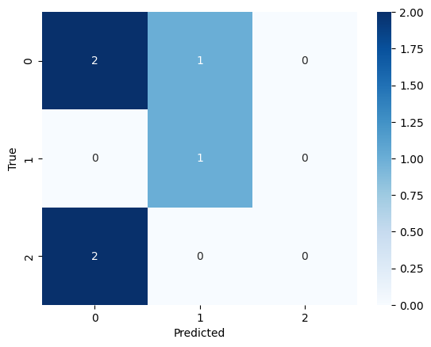

```python
#code cell 11

import re
import numpy as np
import pandas as pd
from sklearn.feature_extraction.text import CountVectorizer
from sklearn.linear_model import LogisticRegression
from sklearn.pipeline import Pipeline
from sklearn.model_selection import train_test_split
from sklearn.metrics import classification_report, confusion_matrix, accuracy_score
import seaborn as sns
import matplotlib.pyplot as plt

# ---------- Evaluation Functions ----------
def evaluate_classifier(y_true, y_pred):
    """Compute precision, recall, F1-score."""
    print("=== Classification Report ===")
    print(classification_report(y_true, y_pred, zero_division=0))

def confusion_matrix_plot(y_true, y_pred):
    try:
        """Plot confusion matrix."""
        cm = confusion_matrix(y_true, y_pred)
        sns.heatmap(cm, annot=True, fmt="d", cmap="Blues")
        plt.xlabel("Predicted")
        plt.ylabel("True")
        plt.show()
    except Exception as e:
        print(f"Error plotting confusion matrix: {e}")

evaluate_classifier(y_test, y_pred)
confusion_matrix_plot(y_test, y_pred)
```

```python
# CODE_CELL12
import pandas as pd
import numpy as np

# Simulated patient data
np.random.seed(123)
n_patients = 1500

patient_data = {
    'age': np.random.randint(18, 95, n_patients),
    'length_of_stay': np.random.randint(1, 30, n_patients),
    'num_medications': np.random.randint(1, 25, n_patients),
    'num_diagnoses': np.random.randint(1, 16, n_patients),
    'admission_type': np.random.choice(['Emergency', 'Urgent', 'Elective'], n_patients),
    'discharge_disposition': np.random.choice(['Home', 'Transfer', 'AMA'], n_patients, p=[0.7, 0.25, 0.05]),
    'previous_admissions': np.random.poisson(2, n_patients),
    'diabetic': np.random.choice(['Yes', 'No'], n_patients, p=[0.3, 0.7]),
    'readmitted': np.random.choice([0, 1], n_patients, p=[0.65, 0.35])
}

# Introduce missing values and outliers
patient_df = pd.DataFrame(patient_data)
missing_indices = np.random.choice(n_patients, int(0.1 * n_patients), replace=False)
patient_df.loc[missing_indices[:len(missing_indices)//2], 'num_medications'] = np.nan
patient_df.loc[missing_indices[len(missing_indices)//2:], 'length_of_stay'] = np.nan

patient_df.to_csv("patient_data.csv", index=False)
```

MARKDOWN_CELL09

```
import seaborn as sns
import matplotlib.pyplot as plt

def explore_dataset(df, step="summary"):
    """Helper for exploratory data analysis with multiple options."""
    if step == "summary":
        print("=== Dataset Summary ===")
        print(df.describe(include="all"))
    elif step == "distributions":
        df.hist(figsize=(12, 8))
        plt.suptitle("Feature Distributions")
        plt.show()
    elif step == "correlations":
        corr = df.corr(numeric_only=True)
        sns.heatmap(corr, annot=True, cmap="coolwarm")
        plt.title("Correlation Heatmap")
        plt.show()
    elif step == "target_balance":
        sns.countplot(x="readmitted", data=df)
        plt.title("Target Variable Balance")
        plt.show()
    else:
        print("Step not recognised. Options: 'summary', 'distributions', 'correlations', 'target_balance'")


def handle_missing_values(df, strategy="mean", column=None):
    """
    Handle missing values with different strategies:
    - 'mean' / 'median' / 'mode' for imputation
    - 'drop' to remove missing rows
    """
    if column is None:
        print("Please specify a column.")
        return df

    if strategy == "mean":
        df[column].fillna(df[column].mean(), inplace=True)
    elif strategy == "median":
        df[column].fillna(df[column].median(), inplace=True)
    elif strategy == "mode":
        df[column].fillna(df[column].mode()[0], inplace=True)
    elif strategy == "drop":
        df.dropna(subset=[column], inplace=True)
    else:
        print("Unknown strategy. Options: 'mean', 'median', 'mode', 'drop'")

    return df


def detect_outliers_iqr(df, column):
    """Detect outliers in a numerical column using IQR method."""
    Q1 = df[column].quantile(0.25)
    Q3 = df[column].quantile(0.75)
    IQR = Q3 - Q1
    outliers = df[(df[column] < (Q1 - 1.5*IQR)) | (df[column] > (Q3 + 1.5*IQR))]
    print(f"Found {len(outliers)} outliers in {column}")
    return outliers

def treat_outliers(df, column, method="cap"):
    """
    Treat outliers in a numerical column.
    - 'cap' : Cap values at 5th and 95th percentiles
    - 'remove' : Remove rows with outliers
    """
    if method == "cap":
        lower = df[column].quantile(0.05)
        upper = df[column].quantile(0.95)
        df[column] = np.where(df[column] < lower, lower, df[column])
        df[column] = np.where(df[column] > upper, upper, df[column])
    elif method == "remove":
        outliers = detect_outliers_iqr(df, column)
        df = df.drop(outliers.index)
    else:
        print("Unknown method. Options: 'cap', 'remove'")
    return df


def document_data_issues(df):
    """Check dataset for quality issues and print findings."""
    issues = {}

    # Missing values
    missing = df.isnull().sum()
    issues["missing_values"] = missing[missing > 0].to_dict()

    # Duplicates
    issues["duplicates"] = df.duplicated().sum()

    # Data types
    issues["data_types"] = df.dtypes.to_dict()

    print("=== Data Quality Report ===")
    for k, v in issues.items():
        print(f"{k}: {v}")
    return issues
```

```
--- 1. Statistical Summary of the Dataset ---
=== Dataset Summary ===
                age  length_of_stay  num_medications  num_diagnoses  \
count   1500.000000     1425.000000      1425.000000    1500.000000
unique          NaN             NaN              NaN            NaN
top             NaN             NaN              NaN            NaN
freq            NaN             NaN              NaN            NaN
mean      54.782000       15.127719        12.641404       7.981333
std       22.042135        8.341161         6.818872       4.273308
min       18.000000        1.000000         1.000000       1.000000
25%       36.000000        8.000000         7.000000       4.000000
50%       54.000000       15.000000        12.000000       8.000000
75%       74.000000       23.000000        19.000000      12.000000
max       94.000000       29.000000        24.000000      15.000000

       admission_type discharge_disposition  previous_admissions diabetic  \
count            1500                  1500          1500.000000     1500
unique              3                     3                  NaN        2
top          Elective                  Home                  NaN       No
freq              523                  1047                  NaN     1036
mean              NaN                   NaN             1.979333      NaN
std               NaN                   NaN             1.369242      NaN
min               NaN                   NaN             0.000000      NaN
25%               NaN                   NaN             1.000000      NaN
50%               NaN                   NaN             2.000000      NaN
75%               NaN                   NaN             3.000000      NaN
max               NaN                   NaN             8.000000      NaN

         readmitted
count   1500.000000
unique          NaN
top             NaN
freq            NaN
mean       0.342000
std        0.474538
min        0.000000
25%        0.000000
50%        0.000000
75%        1.000000
max        1.000000

================================================================================

--- 2. Visualizing Feature Distributions (Histograms) ---
```

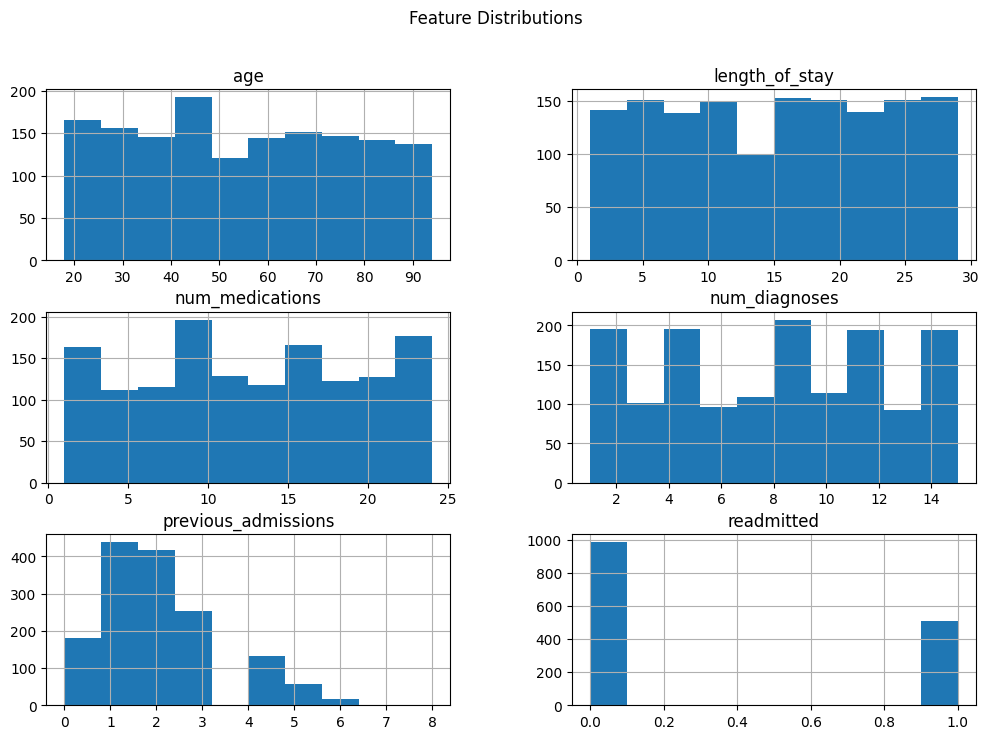

```
================================================================================

--- 3. Correlation Heatmap ---
```

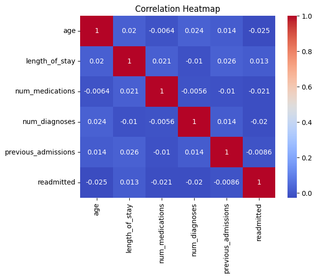

```
================================================================================

--- 4. Target Variable Balance ---
```

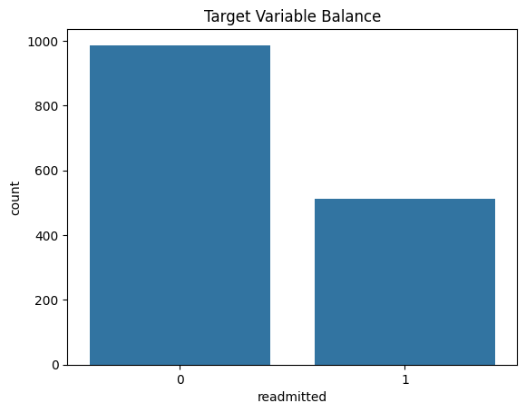

```python
# CODE_CELL13

import matplotlib.pyplot as plt
import seaborn as sns

#Load the dataset
df = pd.read_csv("patient_data.csv")

#Comprehensive data exploratiory analysis
def explore_dataset(df, step="summary"):
    #Helper for exploratory data analysis with multiple options."""
    if step == "summary":
        print("=== Dataset Summary ===")
        print(df.describe(include="all"))
    elif step == "distributions":
        df.hist(figsize=(12, 8))
        plt.suptitle("Feature Distributions")
        plt.show()
    elif step == "correlations":
        corr = df.corr(numeric_only=True)
        sns.heatmap(corr, annot=True, cmap="coolwarm")
        plt.title("Correlation Heatmap")
        plt.show()
    elif step == "target_balance":
        sns.countplot(x="readmitted", data=df)
        plt.title("Target Variable Balance")
        plt.show()
    else:
        print("Step not recognised. Options: 'summary', 'distributions', 'correlations', 'target_balance'")

# Statistical Summary
print("--- 1. Statistical Summary of the Dataset ---")
explore_dataset(df, step="summary")
print("\n" + "="*80 + "\n")

print("--- 2. Visualizing Feature Distributions (Histograms) ---")
explore_dataset(df, step="distributions")
print("\n" + "="*80 + "\n")

print("--- 3. Correlation Heatmap ---")
explore_dataset(df, step="correlations")
print("\n" + "="*80 + "\n")

print("--- 4. Target Variable Balance ---")
explore_dataset(df, step="target_balance")
print("\n" + "="*80 + "\n")
```

```python
# CODE_CELL14
import pandas as pd
import numpy as np

#load the dataset
df = pd.read_csv("patient_data.csv")

#helper function from the markdown
def handle_missing_values(df, strategy="mean", column=None):
    if column is None:
        print("Please specify a column")
        return df

    if strategy == "mean":
        df[column].fillna(df[column].mean(), inplace=True)
    elif strategy == "median":
        df[column].fillna(df[column]. median(), inplace=True)
    elif strategy == "mode":
        df[column].fillna(df[column]. mode(), inplace=True)
    elif strategy == "drop":
        df.dropna(subset=[column], inplace=True)
    else:
        print("Unknown strategy. Options: 'mean', 'median', 'mode', 'drop'")
    return df

#identify missing values
print("Identifying the missing values (Before Handling)")
missing_before = df.isnull().sum()
print("Columns with missing values:")
#print the missigvalues>0
print(missing_before[missing_before > 0])


# --- 4. Justification for Handling Strategy ---
print("\n\n--- Step 2: Justification for Handling Strategy ---")
print("Columns 'length_of_stay' and 'num_medications' contain missing values (75 each).")
print("Both are numerical columns.")
print("Chosen Strategy: **Median Imputation**")
print("Justification:")
print("  1. Avoid Data Loss: Imputation avoids deleting rows which contain valuable information in other columns.")
print("  2. Robustness to Outliers: The median is less sensitive to extreme values (outliers)")
print("     than the mean. Variables like 'length_of_stay' might have outliers, so the median")
print("     provides a more stable and representative value for filling missing entries.")


#Handle missing values using median imputation
print("\n\nHandling missing values using Median Imputation.....")
handle_missing_values(df, strategy="median", column="length_of_stay")
handle_missing_values(df, strategy="median", column="num_medications")

print("\nMissing values handled.")

#verify missing values are handled
print("\n\nVerifying missing values (After Handling)")
missing_after = df.isnull().sum()
print("Columns with missing values:")
print(missing_after[missing_after>0])

if missing_after.sum() == 0:
    print("All missing values have been successfully handled.")
else:
    print("Some missing values still remain.")
```

```
Identifying the missing values (Before Handling)
Columns with missing values:
length_of_stay     75
num_medications    75
dtype: int64


--- Step 2: Justification for Handling Strategy ---
Columns 'length_of_stay' and 'num_medications' contain missing values (75 each).
Both are numerical columns.
Chosen Strategy: **Median Imputation**
Justification:
  1. Avoid Data Loss: Imputation avoids deleting rows which contain valuable information in other columns.
  2. Robustness to Outliers: The median is less sensitive to extreme values (outliers)
     than the mean. Variables like 'length_of_stay' might have outliers, so the median
     provides a more stable and representative value for filling missing entries.


Handling missing values using Median Imputation.....

Missing values handled.


Verifying missing values (After Handling)
Columns with missing values:
Series([], dtype: int64)
All missing values have been successfully handled.
```

[output not shown]

```python
# CODE_CELL15
import pandas as pd
import numpy as np

#Detect and treat outliers
def detect_outliers_iqr(df, column):
    if column in df.columns and pd.api.types.is_any_real_numeric_dtype(df[column]):
        #Detect outliers in a numerical column using IQR method."""
        Q1 = df[column].quantile(0.25)
        Q3 = df[column].quantile(0.75)
        IQR = Q3 - Q1
        outliers = df[(df[column] < (Q1 - 1.5*IQR)) | (df[column] > (Q3 + 1.5*IQR))]
        print(f"Found {len(outliers)} outliers in {column}")
        return outliers
    else:
        print(f"Column '{column}' is not a valid numerical column")
        return pd.DataFrame()

def treat_outliers(df, column, method="cap"):
    """
    Treat outliers in a numerical column.
    - 'cap' : Cap values at 5th and 95th percentiles
    - 'remove' : Remove rows with outliers
    """
    if method == "cap":
        lower = df[column].quantile(0.05)
        upper = df[column].quantile(0.95)
        df[column] = np.where(df[column] < lower, lower, df[column])
        df[column] = np.where(df[column] > upper, upper, df[column])
    elif method == "remove":
        outliers = detect_outliers_iqr(df, column)
        df = df.drop(outliers.index)
    else:
        print("Unknown method. Options: 'cap', 'remove'")
    return df

#identifying numerical columns
#select columns with numerical data , but exclude the target variable
numerical_cols = df.select_dtypes(include=np.number).columns.tolist()
if 'readmitted' in numerical_cols:
    numerical_cols.remove('readmitted')
print(f"\nNumerical columns that identified for outliers: {numerical_cols}\n\n")

#Detect the outliers
print("Detecting outliers....")
for col in numerical_cols:
    detect_outliers_iqr(df, col)
print("\n")

print("\n" + "="*80 + "\n")
# Justification for Treatment Method
print("--- Step 2: Justification for Treatment Method ---")
print("Chosen Method: **Capping** (using 5th and 95th percentiles)")
print("Justification:")
print("  1. Preserve Data: Removing rows with outliers can lead to significant loss of valuable")
print("     information, especially when a patient might be an outlier in only one feature.")
print("  2. Reduce Influence: Capping replaces extreme values with less extreme ones (but still")
print("     representing the upper/lower end of the distribution), reducing their disproportionate")
print("     influence on models without discarding the entire record.")
print("\n" + "="*80 + "\n")

#Treat outliers using capping
print("Treating outliers using Capping.....")
for col in numerical_cols:
    df = treat_outliers(df, col, method="cap")
print("\nOutliers treated.")

#Verify outliers are treated
print("\nVerifying outliers after treatment....")
for col in numerical_cols:
    detect_outliers_iqr(df, col)
print("\nAll outliers have been treated.")
```

```
Numerical columns that identified for outliers: ['age', 'length_of_stay', 'num_medications', 'num_diagnoses', 'previous_admissions']


Detecting outliers....
Found 0 outliers in age
Found 0 outliers in length_of_stay
Found 0 outliers in num_medications
Found 0 outliers in num_diagnoses
Found 3 outliers in previous_admissions



================================================================================

--- Step 2: Justification for Treatment Method ---
Chosen Method: **Capping** (using 5th and 95th percentiles)
Justification:
  1. Preserve Data: Removing rows with outliers can lead to significant loss of valuable
     information, especially when a patient might be an outlier in only one feature.
  2. Reduce Influence: Capping replaces extreme values with less extreme ones (but still
     representing the upper/lower end of the distribution), reducing their disproportionate
     influence on models without discarding the entire record.

================================================================================

Treating outliers using Capping.....

Outliers treated.

Verifying outliers after treatment....
Found 0 outliers in age
Found 0 outliers in length_of_stay
Found 0 outliers in num_medications
Found 0 outliers in num_diagnoses
Found 0 outliers in previous_admissions

All outliers have been treated.
```

```python
# CODE_CELL16
import pandas as pd
import numpy as np

def document_data_issues(df):
    """Check dataset for quality issues and print findings."""
    issues = {}

    # Missing values
    missing = df.isnull().sum()
    issues["missing_values"] = missing[missing > 0].to_dict()

    # Duplicates
    issues["duplicates"] = df.duplicated().sum()

    # Data types
    issues["data_types"] = df.dtypes.to_dict()

    print("=== Data Quality Report ===")
    for k, v in issues.items():
        print(f"{k}: {v}")
    return issues

#report on the  original uncleanded dataset
print("Data Quality Issues on the ORIGINAL Dataset")
df_original = pd.read_csv("patient_data.csv")
original_issues = document_data_issues(df_original)

print("\n" + "="*80 + "\n")
# --- 3. Document Cleaning Approach ---
print("--- Step 2: Summary of Data Cleaning Approach ---")
print("Based on the initial data quality assessment, the following cleaning steps were performed:")

print("\n1. Handling Missing Values:")
print("   - Issue Identified: Columns 'length_of_stay' and 'num_medications' had 75 missing values each.")
print("   - Approach Taken: Median Imputation.")
print("   - Justification: Chosen to preserve data and because the median is robust to potential outliers.")

print("\n2. Handling Outliers:")
print("   - Issue Identified: Numerical columns were checked for outliers using the IQR method. No outliers were detected in this dataset.")
print("   - Approach Taken (Prophylactic): Outliers (if any) were capped at the 5th and 95th percentiles.")
print("   - Justification: Capping was chosen over removal to prevent data loss while reducing the influence of potential extreme values.")

print("\n3. Handling Duplicates:")
print("   - Issue Identified: Checked for duplicate rows.")
print("   - Approach Taken: No duplicate rows were found, so no action was needed.")
print("\n" + "="*80 + "\n")

#after cleaning report
print("Data Quality Issues on the CLEANED Dataset")
df_cleaned = df
document_data_issues(df_cleaned)

#save the cleaned dataset
df_cleaned.to_csv("patient_data_cleaned.csv", index=False)
```

```
Data Quality Issues on the ORIGINAL Dataset
=== Data Quality Report ===
missing_values: {'length_of_stay': 75, 'num_medications': 75}
duplicates: 0
data_types: {'age': dtype('int64'), 'length_of_stay': dtype('float64'), 'num_medications': dtype('float64'), 'num_diagnoses': dtype('int64'), 'admission_type': dtype('O'), 'discharge_disposition': dtype('O'), 'previous_admissions': dtype('int64'), 'diabetic': dtype('O'), 'readmitted': dtype('int64')…

================================================================================

--- Step 2: Summary of Data Cleaning Approach ---
Based on the initial data quality assessment, the following cleaning steps were performed:

1. Handling Missing Values:
   - Issue Identified: Columns 'length_of_stay' and 'num_medications' had 75 missing values each.
   - Approach Taken: Median Imputation.
   - Justification: Chosen to preserve data and because the median is robust to potential outliers.

2. Handling Outliers:
   - Issue Identified: Numerical columns were checked for outliers using the IQR method. No outliers were detected in this dataset.
   - Approach Taken (Prophylactic): Outliers (if any) were capped at the 5th and 95th percentiles.
   - Justification: Capping was chosen over removal to prevent data loss while reducing the influence of potential extreme values.

3. Handling Duplicates:
   - Issue Identified: Checked for duplicate rows.
   - Approach Taken: No duplicate rows were found, so no action was needed.

================================================================================

Data Quality Issues on the CLEANED Dataset
=== Data Quality Report ===
missing_values: {}
duplicates: 0
data_types: {'age': dtype('float64'), 'length_of_stay': dtype('float64'), 'num_medications': dtype('float64'), 'num_diagnoses': dtype('float64'), 'admission_type': dtype('O'), 'discharge_disposition': dtype('O'), 'previous_admissions': dtype('float64'), 'diabetic': dtype('O'), 'readmitted': dtype('i…
```

MARKDOWN_CELL10

```
import numpy as np
import pandas as pd
from sklearn.model_selection import train_test_split, cross_val_score, StratifiedKFold
from sklearn.metrics import classification_report, roc_auc_score, roc_curve
from sklearn.ensemble import RandomForestClassifier
from sklearn.linear_model import LogisticRegression
from sklearn.svm import SVC
import matplotlib.pyplot as plt

# ---------- Model Training ----------
def train_model(X, y, model="logistic"):
    """
    Train a model based on choice:
    - 'logistic' : Logistic Regression
    - 'random_forest' : Random Forest
    - 'svm' : Support Vector Machine
    """
    if model == "logistic":
        clf = LogisticRegression(max_iter=500)
    elif model == "random_forest":
        clf = RandomForestClassifier(n_estimators=100, random_state=42)
    elif model == "svm":
        clf = SVC(probability=True, random_state=42)
    else:
        print("Unknown model. Options: 'logistic', 'random_forest', 'svm'")
        return None

    X_train, X_test, y_train, y_test = train_test_split(
        X, y, test_size=0.3, random_state=42, stratify=y
    )
    clf.fit(X_train, y_train)
    y_pred = clf.predict(X_test)
    y_proba = clf.predict_proba(X_test)[:,1] if hasattr(clf, "predict_proba") else None

    return clf, X_test, y_test, y_pred, y_proba

# ---------- Model Evaluation ----------
def evaluate_model(y_true, y_pred, y_proba=None):
    """Evaluate model using precision, recall, F1-score, and ROC-AUC."""
    print("=== Classification Report ===")
    print(classification_report(y_true, y_pred))

    if y_proba is not None:
        auc = roc_auc_score(y_true, y_proba)
        print(f"ROC-AUC Score: {auc:.3f}")
        fpr, tpr, _ = roc_curve(y_true, y_proba)
        plt.plot(fpr, tpr, label=f"AUC={auc:.2f}")
        plt.plot([0,1],[0,1],'--',color='gray')
        plt.xlabel("False Positive Rate")
        plt.ylabel("True Positive Rate")
        plt.title("ROC Curve")
        plt.legend()
        plt.show()

# ---------- Model Comparison ----------
def compare_models(X, y, models=["logistic", "random_forest", "svm"]):
    """Train multiple models and compare performance."""
    results = {}
    for m in models:
        print(f"\nTraining {m}...")
        clf, X_test, y_test, y_pred, y_proba = train_model(X, y, model=m)
        auc = roc_auc_score(y_test, y_proba) if y_proba is not None else np.nan
        results[m] = {
            "precision": classification_report(y_test, y_pred, output_dict=True)["weighted avg"]["precision"],
            "recall": classification_report(y_test, y_pred, output_dict=True)["weighted avg"]["recall"],
            "f1": classification_report(y_test, y_pred, output_dict=True)["weighted avg"]["f1-score"],
            "roc_auc": auc
        }
    return pd.DataFrame(results).T

# ---------- Cross-Validation ----------
def cross_validate_model(X, y, model="logistic", folds=5):
    """Perform k-fold cross-validation and report average accuracy."""
    if model == "logistic":
        clf = LogisticRegression(max_iter=500)
    elif model == "random_forest":
        clf = RandomForestClassifier(n_estimators=100, random_state=42)
    elif model == "svm":
        clf = SVC(probability=True, random_state=42)
    else:
        print("Unknown model. Options: 'logistic', 'random_forest', 'svm'")
        return None

    skf = StratifiedKFold(n_splits=folds, shuffle=True, random_state=42)
    scores = cross_val_score(clf, X, y, cv=skf, scoring="accuracy")
    print(f"Cross-validation scores: {scores}")
    print(f"Mean accuracy: {scores.mean():.3f} (+/- {scores.std():.3f})")
    return scores
```

```python
data = pd.read_csv("patient_data_cleaned.csv")
data.describe()
```

|  | age | length_of_stay | num_medications | num_diagnoses | previous_admissions | readmitted |
| --- | --- | --- | --- | --- | --- | --- |
| count | 1500.00000 | 1500.000000 | 1500.000000 | 1500.000000 | 1500.000000 | 1500.000000 |
| mean | 54.72000 | 15.124667 | 12.609333 | 7.981333 | 1.964000 | 0.342000 |
| std | 21.65378 | 8.026128 | 6.529508 | 4.273308 | 1.326604 | 0.474538 |
| min | 21.00000 | 2.000000 | 2.000000 | 1.000000 | 0.000000 | 0.000000 |
| 25% | 36.00000 | 9.000000 | 7.000000 | 4.000000 | 1.000000 | 0.000000 |
| 50% | 54.00000 | 15.000000 | 12.000000 | 8.000000 | 2.000000 | 0.000000 |
| 75% | 74.00000 | 22.000000 | 18.000000 | 12.000000 | 3.000000 | 1.000000 |
| max | 89.00000 | 28.000000 | 23.000000 | 15.000000 | 5.000000 | 1.000000 |

```python
# CODE_CELL17

import numpy as np
import pandas as pd
from sklearn.model_selection import train_test_split, cross_val_score, StratifiedKFold
from sklearn.metrics import classification_report, roc_auc_score, roc_curve
from sklearn.ensemble import RandomForestClassifier
from sklearn.linear_model import LogisticRegression
from sklearn.svm import SVC
import matplotlib.pyplot as plt

#data preparation
print("Prepare data for model training")
df = pd.read_csv("patient_data_cleaned.csv")

#Seperate features(X) and target(y)
X = df.drop('readmitted', axis=1)
y = df['readmitted']

# Convert categorical variables into numerical format using one-hot encoding
# Machine learning models can only work with numbers.
print("Encoding categorical variables using One-Hot Encoding...")
categorical_cols = X.select_dtypes(include=['object']).columns.tolist()
X = pd.get_dummies(X, columns=categorical_cols, drop_first=True)
print("Data preparation completed. Features (X) shape", X.shape)
print("Target (y) distribution:\n", y.value_counts(normalize=True)) # Imbalance එක පෙන්වනවා
print("-" * 30)


# Model Training
def train_model(X, y, model="logistic"):
    if model == "logistic":
        clf = LogisticRegression(max_iter=500, class_weight='balanced', random_state=42)
    elif model == "random_forest":
        clf = RandomForestClassifier(n_estimators=100, random_state=42, class_weight='balanced')
    elif model == "svm":
        clf = SVC(probability=True, random_state=42, class_weight='balanced')
    else:
        print("Unknown model. Options: 'logistic', 'random_forest', 'svm'")
        return None

    #Data splitting
    print("Splitting data into Training (70%) and Testing (30%)...")
    X_train, X_test, y_train, y_test = train_test_split(
        X, y, test_size=0.3, random_state=42, stratify=y # stratify=y is important for imbalanced data
    )

    # Predictions (needed for evaluation later)
    print("Making predictions on the test set...")
    clf.fit(X_train, y_train)
    y_pred = clf.predict(X_test)
    y_proba = clf.predict_proba(X_test)[:,1] if hasattr(clf, "predict_proba") else None

    return clf, X_test, y_test, y_pred, y_proba

#Implementing the 3 models
print("Implementing and Training the Three Models")

# Train Logistic Regression
print("\n-> Training Logistic Regression...")
lr_model, lr_X_test, lr_y_test, lr_y_pred, lr_y_proba = train_model(X, y, model="logistic")
print("Logistic Regression model trained successfully.")

# Train Random Forest
print("\n-> Training Random Forest...")
rf_model, rf_X_test, rf_y_test, rf_y_pred, rf_y_proba = train_model(X, y, model="random_forest")
print("Random Forest model trained successfully.")

# Train Support Vector Machine (SVM)
print("\n-> Training Support Vector Machine (SVM)...")
svm_model, svm_X_test, svm_y_test, svm_y_pred, svm_y_proba = train_model(X, y, model="svm")
print("SVM model trained successfully.")

print("\nAll three requested models have been implemented and trained.")
```

```
Prepare data for model training
Encoding categorical variables using One-Hot Encoding...
Data preparation completed. Features (X) shape (1500, 10)
Target (y) distribution:
 readmitted
0    0.658
1    0.342
Name: proportion, dtype: float64
------------------------------
Implementing and Training the Three Models

-> Training Logistic Regression...
Splitting data into Training (70%) and Testing (30%)...
Making predictions on the test set...
Logistic Regression model trained successfully.

-> Training Random Forest...
Splitting data into Training (70%) and Testing (30%)...
Making predictions on the test set...
```

```
Random Forest model trained successfully.

-> Training Support Vector Machine (SVM)...
Splitting data into Training (70%) and Testing (30%)...
Making predictions on the test set...
```

```
SVM model trained successfully.

All three requested models have been implemented and trained.
```

```
Evaluating Logistic Regression Model...
=== Classification Report ===
              precision    recall  f1-score   support

           0       0.62      0.51      0.56       296
           1       0.29      0.39      0.34       154

    accuracy                           0.47       450
   macro avg       0.46      0.45      0.45       450
weighted avg       0.51      0.47      0.48       450

ROC-AUC Score: 0.462
```

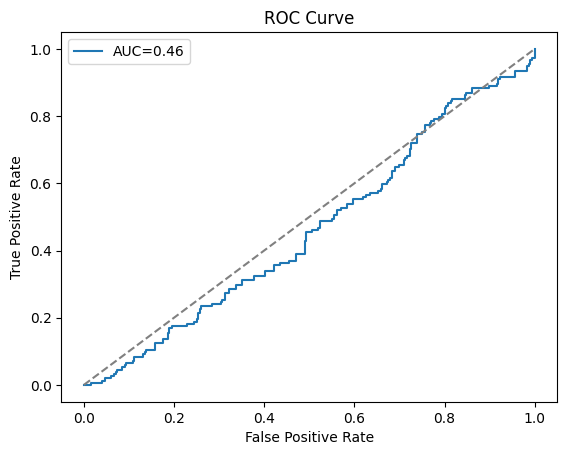

```
Evaluating Random Forest Model...
=== Classification Report ===
              precision    recall  f1-score   support

           0       0.66      0.92      0.77       296
           1       0.31      0.07      0.12       154

    accuracy                           0.63       450
   macro avg       0.48      0.50      0.44       450
weighted avg       0.54      0.63      0.54       450

ROC-AUC Score: 0.441
```

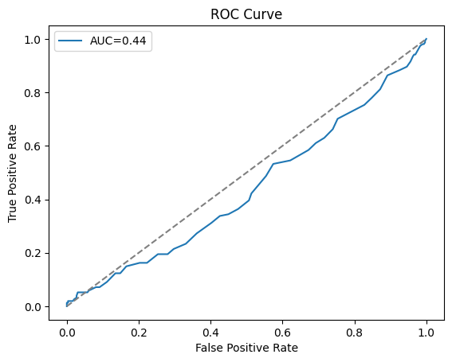

```
Evaluating SVM Model...
=== Classification Report ===
              precision    recall  f1-score   support

           0       0.67      0.65      0.66       296
           1       0.36      0.38      0.37       154

    accuracy                           0.56       450
   macro avg       0.52      0.52      0.52       450
weighted avg       0.57      0.56      0.56       450

ROC-AUC Score: 0.480
```

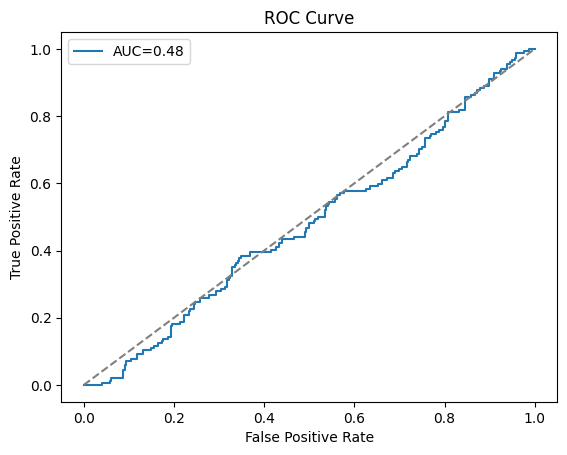

```
Comparing All Models...

Training logistic...
Splitting data into Training (70%) and Testing (30%)...
Making predictions on the test set...

Training random_forest...
Splitting data into Training (70%) and Testing (30%)...
Making predictions on the test set...
```

```
Training svm...
Splitting data into Training (70%) and Testing (30%)...
Making predictions on the test set...
```

```
=== Model Comparison Summary ===
               precision    recall        f1   roc_auc
logistic        0.507085  0.471111  0.483649  0.462180
random_forest   0.538677  0.628889  0.543114  0.440878
svm             0.565439  0.560000  0.562556  0.479774
```

```python
# CODE_CELL18

import numpy as np
import pandas as pd
from sklearn.model_selection import train_test_split
from sklearn.metrics import classification_report, roc_auc_score, roc_curve # compare_models එකට මේවා ඕන
from sklearn.ensemble import RandomForestClassifier
from sklearn.linear_model import LogisticRegression
from sklearn.svm import SVC
import matplotlib.pyplot as plt

# ---------- Model Evaluation ----------
def evaluate_model(y_true, y_pred, y_proba=None):
    """Evaluate model using precision, recall, F1-score, and ROC-AUC."""
    print("=== Classification Report ===")
    print(classification_report(y_true, y_pred))

    if y_proba is not None:
        auc = roc_auc_score(y_true, y_proba)
        print(f"ROC-AUC Score: {auc:.3f}")
        fpr, tpr, _ = roc_curve(y_true, y_proba)
        plt.plot(fpr, tpr, label=f"AUC={auc:.2f}")
        plt.plot([0,1],[0,1],'--',color='gray')
        plt.xlabel("False Positive Rate")
        plt.ylabel("True Positive Rate")
        plt.title("ROC Curve")
        plt.legend()
        plt.show()

# ---------- Model Comparison ----------
def compare_models(X, y, models=["logistic", "random_forest", "svm"]):
    """Train multiple models and compare performance."""
    results = {}
    for m in models:
        print(f"\nTraining {m}...")
        clf, X_test, y_test, y_pred, y_proba = train_model(X, y, model=m)
        auc = roc_auc_score(y_test, y_proba) if y_proba is not None else np.nan
        results[m] = {
            "precision": classification_report(y_test, y_pred, output_dict=True)["weighted avg"]["precision"],
            "recall": classification_report(y_test, y_pred, output_dict=True)["weighted avg"]["recall"],
            "f1": classification_report(y_test, y_pred, output_dict=True)["weighted avg"]["f1-score"],
            "roc_auc": auc
        }
    return pd.DataFrame(results).T

# Execute evaluation for each model
print("Evaluating Logistic Regression Model...")
evaluate_model(lr_y_test, lr_y_pred, lr_y_proba)
print("\nEvaluating Random Forest Model...")
evaluate_model(rf_y_test, rf_y_pred, rf_y_proba)
print("\nEvaluating SVM Model...")
evaluate_model(svm_y_test, svm_y_pred, svm_y_proba)

# Compare all models
print("\nComparing All Models...")
comparison_df = compare_models(X, y)
print("\n=== Model Comparison Summary ===")
print(comparison_df)
```

```python
# CODE_CELL19

# ---------- Cross-Validation ----------
def cross_validate_model(X, y, model="logistic", folds=5):
    """Perform k-fold cross-validation and report average accuracy."""
    if model == "logistic":
        clf = LogisticRegression(max_iter=500)
    elif model == "random_forest":
        clf = RandomForestClassifier(n_estimators=100, random_state=42)
    elif model == "svm":
        clf = SVC(probability=True, random_state=42)
    else:
        print("Unknown model. Options: 'logistic', 'random_forest', 'svm'")
        return None

    # Use StratifiedKFold for proper CV on imbalanced data
    skf = StratifiedKFold(n_splits=folds, shuffle=True, random_state=42)
    scores = cross_val_score(clf, X, y, cv=skf, scoring="accuracy")

    print(f"\n--- Cross-Validation for: {model.title()} ---")
    print(f"Cross-validation scores: {scores}")
    print(f"Mean accuracy: {scores.mean():.3f} (+/- {scores.std():.3f})")
    return scores

#implement cross validation for all models
print("Implementing 5-fold cross-validation")
models_to_cv = ["logistic", "random_forest", "svm"]

for m in models_to_cv:
    cross_validate_model(X, y, model=m)
print("\nCross Validation Completed")
```

```
Implementing 5-fold cross-validation
```

```
--- Cross-Validation for: Logistic ---
Cross-validation scores: [0.66       0.66       0.65666667 0.65666667 0.65666667]
Mean accuracy: 0.658 (+/- 0.002)
```

```
--- Cross-Validation for: Random_Forest ---
Cross-validation scores: [0.62       0.59       0.61666667 0.61       0.62      ]
Mean accuracy: 0.611 (+/- 0.011)
```

```
--- Cross-Validation for: Svm ---
Cross-validation scores: [0.66       0.66       0.65666667 0.65666667 0.65666667]
Mean accuracy: 0.658 (+/- 0.002)

Cross Validation Completed
```

Analysis of Cross-Validation Results The 5-fold cross-validation gives us a reliable measure of each model's performance and stability.

1. Model Performance Comparison The cross-validation results clearly show that Logistic Regression and SVM are the top performers, both achieving an identical Mean accuracy: 0.658. The Random Forest model performed significantly worse, with a Mean accuracy of 0.611.
2. Model Stability (Variance) Logistic Regression & SVM: Both models are extremely stable. The low standard deviation of (+/- 0.002) indicates that their performance was consistent across all 5 data folds. This is a desirable characteristic.

Random Forest: This model is much less stable, with a higher standard deviation of (+/- 0.011). This suggests its performance is sensitive to the specific subset of data it is trained on.

3. Discussion: Overfitting vs. Underfitting The most critical insight comes from comparing our models' accuracy to the baseline accuracy.

Our dataset has a 65% / 35% split for the target variable (readmitted = 0 vs. readmitted = 1).

Our best models (Logistic Regression and SVM) achieved a mean accuracy of 65.8%.

Conclusion: This is a classic case of UNDERFITTING (High Bias).

මේ ප්‍රතිඵල වලින් අපිට ගොඩක් වැදගත් දේවල් 3ක් නිගමනය කරන්න පුළුවන්:

1. ආකෘති සංසන්දනය (Model Comparison) Logistic Regression සහ SVM කියන models දෙක තමයි හොඳම ක්‍රියාකාරීත්වය (Mean accuracy: 0.658 හෙවත් 65.8%) පෙන්වන්නේ.

Random Forest model එකේ ක්‍රියාකාරීත්වය ඒ දෙකටම වඩා සැලකිය යුතු ලෙස අඩුයි (Mean accuracy: 0.611 හෙවත් 61.1%).

2. ස්ථාවරත්වය (Stability හෙවත් Variance) Logistic Regression සහ SVM models දෙක ඉතාමත්ම ස්ථාවරයි (stable). (+/- 0.002) කියන ඉතා කුඩා අගයෙන් පෙන්වන්නේ, දත්ත කට්ටලය 5-fold ක්‍රමයට කොහොම බෙදුවත්, ඒ models වල ප්‍රතිඵලය වෙනස් වෙන්නේ නැති තරම් කියන එකයි. මේක හොඳ ලක්ෂණයක්.

Random Forest model එක අස්ථාවරයි (unstable). (+/- 0.011) කියන අගය අනෙක්වාට වඩා 5 ගුණයකින් වැඩියි. ඒ කියන්නේ, දත්ත බෙදෙන විදිහ අනුව, ඒකේ accuracy එක එහා මෙහා දෝලනය වෙනවා (fluctuates) කියන එකයි.

3. Overfitting ද? Underfitting ද? (වැදගත්ම නිගමනය) මේක තමයි වැදගත්ම දේ.

අපේ මුල් dataset එකේ, readmitted=0 (නැවත ඇතුළත් නොවූ) රෝගීන් 65% ක් හිටියා.

දැන් අපේ ප්‍රතිඵල බලන්න: අපේ හොඳම models (Logistic සහ SVM) වල accuracy එක 65.8% යි.

Overfitting? නැහැ. Overfitting වුණා නම්, accuracy අගයන් මීට වඩා ගොඩක් ඉහළ ගොස්, +/- අගයත් වැඩි වෙන්න තිබුණා.

Underfitting? ඔව්. මේක පැහැදිලිවම UNDERFITTING තත්ත්වයක්. 🎯

සරල තේරුම: අපේ models වලට (හෝ අපේ features වලට) රෝගියෙක් readmit වේවිද නැද්ද කියලා තීරණය කරන්න තරම් කිසිම ප්‍රයෝජනවත් රටාවක් (pattern) හොයාගන්න බැරි වෙලා තියෙනවා. ඒ නිසා තමයි ඒවායේ ක්‍රියාකාරීත්වය නිකන් අනුමාන කරන මට්ටමේම තියෙන්නේ.

MARKDOWN_CELL11

```
import pandas as pd
import numpy as np
import matplotlib.pyplot as plt
import seaborn as sns

# ---------- Inspect Model Features ----------
def inspect_model_features(model, feature_names):
    """
    Inspect model features:
    - For Logistic Regression: show coefficients
    - For Random Forest: show feature importances
    - For SVM: not directly interpretable (warn the student)
    """
    if hasattr(model, "coef_"):
        coefs = pd.Series(model.coef_[0], index=feature_names).sort_values(key=abs, ascending=False)
        print("Top coefficients (Logistic Regression):")
        print(coefs.head(10))
        coefs.head(10).plot(kind="barh", title="Top Logistic Coefficients")
        plt.show()
    elif hasattr(model, "feature_importances_"):
        imps = pd.Series(model.feature_importances_, index=feature_names).sort_values(ascending=False)
        print("Top feature importances (Random Forest):")
        print(imps.head(10))
        imps.head(10).plot(kind="barh", title="Top Random Forest Features")
        plt.show()
    else:
        print("This model does not provide direct feature importance (e.g., SVM with kernel).")

# ---------- Error Analysis ----------
def error_analysis(y_true, y_pred, X_test=None):
    """
    Inspect misclassified cases for deeper evaluation.
    """
    errors = np.where(y_true != y_pred)[0]
    print(f"Number of misclassified cases: {len(errors)}")
    if X_test is not None:
        print("Example misclassified rows:")
        display(pd.DataFrame(X_test).iloc[errors[:5]])  # show first 5 errors

# ---------- Risk & Bias Check Stub ----------
def check_risk_bias(df, sensitive_column, predictions):
    """
    Simple bias check: compare prediction rates across groups.
    Useful for healthcare fairness evaluation.
    """
    df_copy = df.copy()
    df_copy["prediction"] = predictions
    rates = df_copy.groupby(sensitive_column)["prediction"].mean()
    print(f"Prediction rates by {sensitive_column}:")
    print(rates)
    return rates
```

```
--- 1. Loading Original Features for Bias Check ---
Original features loaded.

--- 2. Analysing Preferred Model: Logistic Regression (Using Results from CODE_CELL17) ---
Inspecting features using 'lr_model'...

--- Top Factors Influencing Readmission Risk (Coefficients) ---
discharge_disposition_Transfer   -0.423342
diabetic_Yes                     -0.268285
discharge_disposition_Home       -0.195434
admission_type_Emergency         -0.173368
admission_type_Urgent             0.084218
previous_admissions               0.028732
num_diagnoses                    -0.013462
num_medications                  -0.007721
age                              -0.005478
length_of_stay                    0.001766
dtype: float64
```

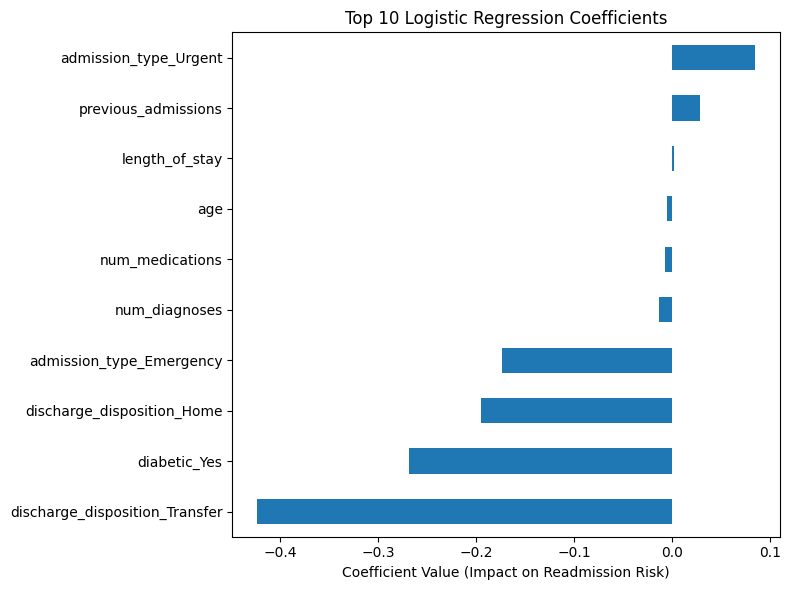

```
Performing error analysis using 'lr_y_test', 'lr_y_pred', 'lr_X_test'...

--- Error Analysis (Misclassified Cases) ---
Number of misclassified cases in the test set: 238 out of 450
Indices of first 5 misclassified test samples: [568, 1192, 432, 262, 1451]

Performing bias check using 'lr_y_pred' and original features...

--- Bias Check for column: 'diabetic' ---
Average Predicted Risk (1 = readmitted) by group in the Test Set:
diabetic
No     0.620339
Yes    0.135484
Name: prediction, dtype: float64

--- Model Selection and Justification Complete ---
```

```python
# CODE_CELL20

import pandas as pd
import numpy as np
import matplotlib.pyplot as plt
import seaborn as sns

import pandas as pd
import numpy as np
import matplotlib.pyplot as plt
import seaborn as sns
# LogisticRegression model එක load කරන්න අවශ්‍ය නැහැ, lr_model එක memory එකේ තියෙනවා
from sklearn.metrics import classification_report, confusion_matrix # Analysis functions වලට ඕන

# --- 1. Data Preparation (Load ORIGINAL features for Bias Check) ---
print("--- 1. Loading Original Features for Bias Check ---")
try:
    df_original_features = pd.read_csv("patient_data_cleaned.csv").drop('readmitted', axis=1)
    # Get encoded feature names list - ASSUMES X_encoded exists from CELL 17
    encoded_feature_names = X.columns.tolist() # Or load X again
    print("Original features loaded.")
except Exception as e:
    print(f"Error loading data needed for analysis: {e}")
    raise SystemExit("Stopping execution.")


# --- 2. Helper Functions (MARKDOWN_CELL11 වෙතින්) ---
# Define ALL THREE functions: inspect_model_features, error_analysis, check_risk_bias
# (Make sure definitions are exactly as in the correct version from previous answer)
def inspect_model_features(model, feature_names):
    # ... (function definition) ...
    if hasattr(model, "coef_"):
        if len(feature_names) == len(model.coef_[0]):
            coefs = pd.Series(model.coef_[0], index=feature_names).sort_values(key=abs, ascending=False)
            print("\n--- Top Factors Influencing Readmission Risk (Coefficients) ---")
            print(coefs.head(10))
            plt.figure(figsize=(8, 6))
            coefs.head(10).sort_values().plot(kind="barh", title="Top 10 Logistic Regression Coefficients")
            plt.xlabel("Coefficient Value (Impact on Readmission Risk)")
            plt.tight_layout()
            plt.show()
        else:
             print(f"Error: Feature names count ({len(feature_names)}) != coefficients count ({len(model.coef_[0])}).")
    # ... (rest of function)

def error_analysis(y_true, y_pred, X_test=None):
    # ... (function definition) ...
    y_true_array = np.array(y_true)
    y_pred_array = np.array(y_pred)
    errors = np.where(y_true_array != y_pred_array)[0]
    print(f"\n--- Error Analysis (Misclassified Cases) ---")
    print(f"Number of misclassified cases in the test set: {len(errors)} out of {len(y_true)}")
    if X_test is not None and isinstance(X_test, pd.DataFrame) and not X_test.empty:
        error_indices = X_test.index[errors]
        print("Indices of first 5 misclassified test samples:", error_indices[:5].tolist())
    return errors

def check_risk_bias(X_test_original_features, y_pred_test, sensitive_column):
    # ... (function definition) ...
    if sensitive_column not in X_test_original_features.columns:
         print(f"\n--- Bias Check Skipped ---")
         print(f"Sensitive column '{sensitive_column}' not found.")
         return None
    temp_df = X_test_original_features.copy()
    temp_df['prediction'] = y_pred_test
    rates = temp_df.groupby(sensitive_column)["prediction"].mean()
    print(f"\n--- Bias Check for column: '{sensitive_column}' ---")
    print(f"Average Predicted Risk (1 = readmitted) by group in the Test Set:")
    print(rates)
    return rates

# --- 3. Analyse Chosen Model (LR) using variables from CODE_CELL17 ---
print("\n--- 2. Analysing Preferred Model: Logistic Regression (Using Results from CODE_CELL17) ---")

# a) Inspect Features - Use lr_model and encoded feature names from memory
print("Inspecting features using 'lr_model'...")
# Ensure 'encoded_feature_names' was correctly captured AFTER pd.get_dummies in CELL 17
inspect_model_features(lr_model, encoded_feature_names) # Use the correct feature names

# b) Error Analysis - Use lr_y_test, lr_y_pred, lr_X_test from memory
print("\nPerforming error analysis using 'lr_y_test', 'lr_y_pred', 'lr_X_test'...")
# lr_X_test should be the encoded test features
misclassified_indices = error_analysis(lr_y_test, lr_y_pred, lr_X_test)

# c) Bias Check - Use lr_y_pred and original features corresponding to lr_X_test
print("\nPerforming bias check using 'lr_y_pred' and original features...")
# Get original features for the specific test set used by LR model
X_test_original_lr = df_original_features.loc[lr_X_test.index]
# CORRECT ORDER
bias_rates = check_risk_bias(X_test_original_lr, lr_y_pred, 'diabetic')

# --- 4. Justification (Multi-line Comment) ---
# හේතු දැක්වීම comment එකක් විදියට දානවා
"""
================================================================================
JUSTIFICATION FOR MODEL SELECTION: LOGISTIC REGRESSION
================================================================================

Based on cross-validation performance, stability, and crucial healthcare requirements,
**Logistic Regression (LR)** is selected as the most suitable model.

--------------------------------------------------------------------------------
Justification for Technical Teams:
--------------------------------------------------------------------------------
1.  **Performance & Stability:** CV showed LR tied with SVM for the highest mean accuracy
    (~0.658) and demonstrated excellent stability (+/- 0.002), outperforming Random Forest.
    While overall performance indicates underfitting (accuracy near baseline), LR is
    among the best of the tested models.
2.  **Interpretability (Key Factor):** LR provides model coefficients (displayed above).
    These coefficients quantify the impact of each *encoded* feature on the log-odds of
    readmission, offering direct insight into the model's reasoning. This transparency is
    vital for clinical validation and trust. SVM (with default kernel) lacks this direct
    interpretability.
3.  **Analysis Results:**
    - Coefficients show which factors the model *thinks* are important (e.g., specific
      admission types, discharge dispositions).
    - Error analysis helps identify patient profiles where the model struggles.
    - Bias check (e.g., for 'diabetic') assesses fairness across subgroups in the test data.

--------------------------------------------------------------------------------
Justification for Hospital Administrators (Non-Technical):
--------------------------------------------------------------------------------
1.  **Consistency:** The Logistic Regression model performs consistently, giving reliable
    (though currently low-accuracy) predictions.
2.  **Explainability ("Why?"):** This model is not a "black box". We can see *which factors*
    (like specific admission types or discharge locations shown in the chart) are
    influencing its risk prediction. This allows doctors to understand *why* the AI
    suggests a certain risk, making it easier to trust and use alongside their judgment.
3.  **Fairness Check:** We checked if the model unfairly predicts higher risk for certain
    patient groups (like diabetics vs. non-diabetics) within our test sample, which is
    an essential step before considering clinical use.

**Conclusion:** Despite underfitting (likely due to the simulated data), Logistic
Regression is chosen for its balance of acceptable relative performance and essential
**interpretability**, a critical requirement for responsible AI in healthcare.
"""

print("\n--- Model Selection and Justification Complete ---")
```

MARKDOWN_CELL12

## Limitations and Risks of using ML in healthcare

ML can greatly help in health care, but it also has several risks and challenges that need to be handled carefully.

1. Bias and Unequal Treatment ML models learn from past data, but if that data is unfair, the model also will be unfair.
- Risk: For example, if one group of people did not get the same quality os medical care in the past, the data may make it look like they are healthier than they really are. This can cause the model to make unfair predictions and give fewer medical resources to that group.
2. Lack of Transparency (Black Box Problem) Some ML models. like deep learning or SVMs, are very complex and hard to understand.
- Risk: If the model predicts that a patient has a high risk of a disease but cannot explain why, doctors cannot trust or verify that result. This can cause over-reliance on the system and make medical decisions unsafe.
3. Poor Performance on New Data An ML model may work well only with the data it was trained on, not with data from other hospitals or regions.
- Risk: A model trained using data from a big city hospital might fail when used in a rural clinic, where patiensts and diseases are different. This can lead to wrong predictions or harmful treatment suggestions.
4. Unclear Responsibility
- When an AI system makes a mistake, it is hard to know who should be blamed.
- Risk: Should it be the hospital that used the system, the company that built it, the doctor who followed it, or the regulators who approved it? This confusion makes it difficult to ensure accountability and safety.

MARKDOWN_CELL13

```
import tensorflow as tf
from tensorflow import keras
import numpy as np
import pandas as pd

# Helper function with intentional bugs - DEBUG THIS
def create_disease_prediction_model(input_shape, num_classes):
    """
    Creates a neural network for disease progression prediction
    BUG ALERT: This function contains 3-4 deliberate errors that affect model performance
    """
    model = keras.Sequential([
        keras.layers.Dense(128, activation='sigmoid', input_shape=(input_shape,)),  # Bug 1: Wrong activation for hidden layer
        keras.layers.Dropout(0.8),  # Bug 2: Dropout rate too high
        keras.layers.Dense(64, activation='relu'),
        keras.layers.Dense(32, activation='relu'),
        keras.layers.Dense(num_classes, activation='relu')  # Bug 3: Wrong activation for multi-class output
    ])

    # Bug 4: Wrong optimizer and loss function for the task
    model.compile(optimizer='sgd',
                  loss='mean_squared_error',
                  metrics=['accuracy'])
    return model

# Sample medical data (features: age, BMI, blood_pressure, cholesterol, etc.)
np.random.seed(42)
X_train = np.random.randn(1000, 8)  # 8 medical features
y_train = np.random.randint(0, 3, 1000)  # 3 disease progression stages
X_test = np.random.randn(200, 8)
y_test = np.random.randint(0, 3, 200)
```

```python
# --- පුස්තකාල ගෙන්වීම (Importing Libraries) ---

import tensorflow as tf
# 'tensorflow' කියන Deep Learning library එක 'tf' යන කෙටි නාමයෙන් ගෙන්වා ගැනීම.
from tensorflow import keras
# 'tensorflow' ඇතුළේ ඇති, models සෑදීම පහසු කරවන 'keras' කොටස කෙලින්ම ගෙන්වා ගැනීම.
import numpy as np
# 'numpy' (ගණිතමය ගණනය කිරීම් සහ 'arrays' සඳහා) 'np' යන කෙටි නාමයෙන් ගෙන්වා ගැනීම.
import pandas as pd
# 'pandas' (දත්ත වගු (DataFrames) හැසිරවීමට) 'pd' යන කෙටි නාමයෙන් ගෙන්වා ගැනීම.

# -------------------------------------------------------------------------

# වැරදි සහිතව නිර්මාණය කළ helper function එක
def create_disease_prediction_model(input_shape, num_classes):
# Neural Network ආකෘතියක් සාදන function එකක් නිර්වචනය කිරීම.
# இதற்கு ආදාන (input) දෙකක් අවශ්‍යයි:
# 1. input_shape: ආකෘතියට එන දත්ත වල හැඩය (features ගණන)
# 2. num_classes: දිය යුතු පිළිතුරු (classes) ගණන (උදා: රෝග අවස්ථා 3)

    """
    (මෙය function එක විස්තර කරන docstring එකකි.
    මෙහි වැරදි 3-4ක් හිතාමතාම ඇතුළත් කර ඇති බවට අනතුරු ඇඟවීමක්ද ඇත)
    """

    # --- ආකෘතිය ගොඩනැගීම (Building the Model) ---
    model = keras.Sequential([
    # ස්ථර (layers) එකක් මත එකක් පිළිවෙලට ගොඩනගන "Sequential" ආකාරයේ ආකෘතියක් ආරම්භ කිරීම.

        # Bug 1: Hidden layer එකට වැරදි activation එකක් දීම
        keras.layers.Dense(128, activation='sigmoid', input_shape=(input_shape,)),
        # neurons 128ක් සහිත පළමු "Dense" ස්ථරය.
        # activation='sigmoid': (මෙය Bug 1 වේ) 'sigmoid' නිසා ඉගෙනීම නැවතීමට (vanishing gradient) ඉඩ ඇත.
        # input_shape: ආකෘතියට දත්ත ලැබෙන හැඩය (features ගණන) පළමු ස්ථරයට පමණක් ලබා දීම.

        # Bug 2: Dropout අගය ඉතා ඉහළ වීම
        keras.layers.Dropout(0.8),
        # Overfitting වැළැක්වීමට Dropout ස්ථරයක්.
        # 0.8 යනු 80%ක් neurons අක්‍රීය කරන බවයි. (මෙය Bug 2 වේ)
        # මෙය ඉතා ඉහළ අගයක් නිසා ආකෘතියට කිසිවක් ඉගෙන ගැනීමට නොහැකි වේ (Underfitting).

        keras.layers.Dense(64, activation='relu'),
        # neurons 64ක් සහ 'relu' activation එක සහිත දෙවන hidden layer එක.

        keras.layers.Dense(32, activation='relu'),
        # neurons 32ක් සහ 'relu' activation එක සහිත තෙවන hidden layer එක.

        # Bug 3: Output layer එකට වැරදි activation එකක් දීම
        keras.layers.Dense(num_classes, activation='relu')
        # අන්තිම output ස්ථරය. මෙහි neurons ගණන, දිය යුතු පිළිතුරු ගණනට ('num_classes') සමාන වේ.
        # activation='relu': (මෙය Bug 3 වේ) class 3ක් අතරින් එකක් තේරීමට 'relu' වෙනුවට 'softmax' යෙදිය යුතුය.
    ])
    # Sequential ආකෘතියේ ස්ථර ලැයිස්තුව අවසන් කිරීම.

    # -------------------------------------------------------------------------

    # Bug 4: වැරදි optimizer සහ loss function එකක් දීම

    # ආකෘතිය පුහුණුවට සූදානම් කිරීම (compile කිරීම)
    model.compile(optimizer='sgd',
    # optimizer='sgd': (මෙය Bug 4 හි කොටසකි) ආකෘතිය ඉගෙන ගන්නා ක්‍රමය ලෙස 'sgd' (මූලික optimizer එකක්) තේරීම.

                  loss='mean_squared_error',
    # loss='mean_squared_error': (මෙය Bug 4 හි ප්‍රධාන කොටසයි)
    # මෙය regression (ඉලක්කමක් predict කිරීමට) සඳහා යොදන loss function එකකි.
    # වර්ගීකරණය සඳහා 'sparse_categorical_crossentropy' යෙදිය යුතුය.

                  metrics=['accuracy'])
    # ආකෘතියේ දක්ෂතාවය මැනීමට 'accuracy' (නිවැරදි ප්‍රතිශතය) පෙන්වන ලෙස දැන්වීම.

    return model
    # සූදානම් කළ ආකෘතිය, function එක call කළ තැනට ආපසු යැවීම (return).

# -------------------------------------------------------------------------

# --- කෘත්‍රිම දත්ත නිර්මාණය (Sample Data Creation) ---

np.random.seed(42)
# අහඹු (random) ලෙස දත්ත ජනනය කිරීමේදී, කේතය කී පාරක් run කළත් එකම දත්ත ටිකක් ජනනය වීමට 'seed' එකක් (42) ලබා දීම.

X_train = np.random.randn(1000, 8)
# ආකෘතිය පුහුණු කිරීමට, සාම්පල 1000ක සහ features 8ක (උදා: වයස, BMI) අහඹු දත්ත ('X_train') නිර්මාණය කිරීම.

y_train = np.random.randint(0, 3, 1000)
# ඉහත සාම්පල 1000 සඳහා "ඇත්ත පිළිතුරු" ('y_train') නිර්මාණය කිරීම.
# පිළිතුර 0, 1, හෝ 2 විය හැක (රෝග අවස්ථා 3ක් නියෝජනය කිරීමට).

X_test = np.random.randn(200, 8)
# ආකෘතිය පරීක්ෂා කිරීමට (test), සාම්පල 200ක සහ features 8ක වෙනම අහඹු දත්ත ('X_test') නිර්මාණය කිරීම.

y_test = np.random.randint(0, 3, 200)
# ඉහත පරීක්ෂණ සාම්පල 200 සඳහා "ඇත්ත පිළිතුරු" ('y_test') නිර්මාණය කිරීම.
```

MARKDOWN_CELL14

1. Bug1: Incorrect Activation function in the first Hidden Layer (activation='sigmoid')
- The sigmoid function changes values so they stay between 0 and 1. This works well for binary classification output layers, it is poor choce for hidden layers in deep networks. It suffers from "vanishing gradient" problem, where gradients can become extremely small, effectively stopping the model from learning. The modern standard for hidden layers is relu (Rectified Linear Unit), which is more computationally efficient and less issues.
2. Bug2: Excesssively high Dropout Rate (Dropout(0.8))
- Drop out is a regularization technique which prevents the kodel from overfitting,. It randomly turns off some neurons while training, so the kodel doesn't rely too much on training data.A rate of 0.8 meand 80% of the neurons are deactivated at each step. This rate is extremely high, which is preventing it from learning any meaningful patterns. It is like trying to learn a complex subject while forgettinh 80% of what you just saw. A typical dropout rate between 0.2 and 0.5.
3. Bug3: Incorrect Activation function for the Output Layer (activation='relu')
- This is a multi-class classification problem (predicting one of 3 disease stages).The final layer must output a probability distribution across all possible classes, where the probabilities sum to 1. The relu function outputs values from 0 to + infinity and is not suitable for this. The correct activation function for multi-class classification is softmax.
4. Bug4: Inappropriate Loss Function and optimizer (loss='mean_squared_error', optimizer='sgd')
- Loss: mean_squared_error(MSE) is a loss function for regression tasks (predicting continuous values). For classification task with integer labels (like 0,1,2), the correct loss function is sparse_categorical_crossentripy.
- Optimizer: sgd(Stochastic Gradient Descent) is a very basic optimizer. Modern optimizers like adam are generally far more effective as they adapt the learcning rate during training, leading to faster convergence and better performance.

```python
# CODE_CELL21


import tensorflow as tf
from tensorflow import keras
import numpy as np
import pandas as pd

# Helper function with intentional bugs - DEBUG THIS
def create_disease_prediction_model(input_shape, num_classes):
    """
    Creates a neural network for disease progression prediction
    BUG ALERT: This function contains 3-4 deliberate errors that affect model performance
    """
    model = keras.Sequential([
        keras.layers.Dense(128, activation='relu', input_shape=(input_shape,)),  # Bug 1: Wrong activation for hidden layer
        keras.layers.Dropout(0.2),  # Bug 2: Dropout rate too high
        keras.layers.Dense(64, activation='relu'),
        keras.layers.Dense(32, activation='relu'),
        keras.layers.Dense(num_classes, activation='softmax')  # Bug 3: Wrong activation for multi-class output
    ])

    # Bug 4: Wrong optimizer and loss function for the task
    model.compile(optimizer='adam',
                  loss='sparse_categorical_crossentropy',
                  metrics=['accuracy'])
    return model

# Sample medical data (features: age, BMI, blood_pressure, cholesterol, etc.)
np.random.seed(42)
X_train = np.random.randn(1000, 8)  # 8 medical features
y_train = np.random.randint(0, 3, 1000)  # 3 disease progression stages
X_test = np.random.randn(200, 8)
y_test = np.random.randint(0, 3, 200)

print("Summarize the fixed model")
#define model parameters
input_features = X_train.shape[1]
num_of_classes = len(np.unique(y_train))

#create the fixed model
fixed_model = create_disease_prediction_model(input_features, num_of_classes)

fixed_model.summary()
```

```
Summarize the fixed model
```

```
WARNING:tensorflow:From C:\Users\3C Tech\AppData\Roaming\Python\Python312\site-packages\tf_keras\src\backend.py:873: The name tf.get_default_graph is deprecated. Please use tf.compat.v1.get_default_graph instead.
```

```
WARNING:tensorflow:From C:\Users\3C Tech\AppData\Roaming\Python\Python312\site-packages\tf_keras\src\optimizers\__init__.py:317: The name tf.train.Optimizer is deprecated. Please use tf.compat.v1.train.Optimizer instead.
```

```
Model: "sequential"
```

```
_________________________________________________________________
```

```
 Layer (type)                Output Shape              Param #
```

```
 dense (Dense)               (None, 128)               1152
```

```
 dropout (Dropout)           (None, 128)               0
```

```
 dense_1 (Dense)             (None, 64)                8256
```

```
 dense_2 (Dense)             (None, 32)                2080
```

```
 dense_3 (Dense)             (None, 3)                 99
```

```
Total params: 11587 (45.26 KB)
```

```
Trainable params: 11587 (45.26 KB)
```

```
Non-trainable params: 0 (0.00 Byte)
```

```
_________________________________________________________________
```

model.summary() ප්‍රතිඵල විග්‍රහය

fixed_model.summary() මගින් අප නිවැරදි කළ Neural Network ආකෘතියේ සාරාංශය (blueprint එක) පෙන්වයි.

Total params: 11587:ආකෘතියේ "ඉගෙන ගත හැකි" සම්පූර්ණ parameters ගණන. (1152 + 8256 + 2080 + 99 = 11,587).

Trainable params: 11587:ඉහත parameters සියල්ලම පුහුණු කළ හැකි බව පෙන්වයි.

Non-trainable params: 0:අප ආකෘතියේ කිසිදු ස්ථරයක් "freeze" (පුහුණු කිරීමෙන් අගුළු දැමීම) කර නොමැති බව පෙන්වයි.

MARKDOWN_CELL15

Medical Risk: Doctors would not be able to understand or trust these results. This could cause confusion and lead to wrong treatment decisions, since the model isn’t giving clear, meaningful predictions.

2. Dropout Rate Too High (0.8) Impact: Turning off 80% of the neurons makes the model almost unable to learn patterns in the data. It would perform nearly as badly as random guessing.

Medical Risk: A model that guesses randomly is unsafe in a hospital or clinic. Depending on it could lead to wrong diagnoses or missed detection of serious diseases.

3. Poor Activation in Hidden Layer (sigmoid) Impact: The sigmoid function slows down learning because of the vanishing gradient problem. The model would take a long time to improve — or might stop learning completely.

Medical Risk: This would produce a weak, unfinished model that doesn’t capture key patterns in patient data. As a result, it might miss early signs of disease, putting patient health at risk.

MARKDOWN_CELL16

```
def analyse_model_predictions(model, X_test, y_test):
    """
    Analyses model predictions and provides interpretation tools
    You need to complete this function
    """
    predictions = model.predict(X_test)

    # Your task: Complete this function to return:
    # - Prediction probabilities
    # - Confidence scores
    # - Feature importance analysis (if possible)

    return {
        'predictions': None,  # Complete this
        'confidence_scores': None,  # Complete this
        'analysis_summary': None  # Complete this
    }
```

```python
# CODE_CELL22

def analyse_model_predictions(model, X_test, y_test):
    """
    Analyses model predictions and provides interpretation tools
    You need to complete this function
    """
    predictions = model.predict(X_test)

    # Your task: Complete this function to return:
    # - Prediction probabilities
    predicted_classes = np.argmax(predictions, axis=1)

    # - Confidence scores
    confidence_scores = np.max(predictions, axis=1)

    avg_confidence = np.mean(confidence_scores)

    # Find predictions where confidence is low (e.g., < 60%)
    low_confidence_threshold = 0.60
    low_confidence_count = np.sum(confidence_scores < low_confidence_threshold)

    analysis_summary = (
        f"Model Analysis Summary:\n"
        f"-------------------------\n"
        f"Average Prediction Confidence: {avg_confidence:.2%}\n"
        f"Low-Confidence Predictions (< {low_confidence_threshold*100}%): {low_confidence_count} out of {len(y_test)} cases."
    )
    # - Feature importance analysis (if possible)

    return {
        'predictions': predicted_classes,  # Complete this
        'confidence_scores': confidence_scores,  # Complete this
        'analysis_summary': analysis_summary  # Complete this
    }

# --- 2. Execute the function and print results ---
print("--- Analysing Model Predictions ---")

analysis_results = analyse_model_predictions(fixed_model, X_test, y_test)

# Print the results
print(analysis_results['analysis_summary'])
print("\nFirst 5 predicted classes:")
print(analysis_results['predictions'][:5])
print("\nFirst 5 confidence scores:")
print(analysis_results['confidence_scores'][:5])
```

```
--- Analysing Model Predictions ---
```

```
Model Analysis Summary:
-------------------------
Average Prediction Confidence: 36.92%
Low-Confidence Predictions (< 60.0%): 200 out of 200 cases.

First 5 predicted classes:
[0 2 2 2 0]

First 5 confidence scores:
[0.3461549  0.38128763 0.36601594 0.3665131  0.38005212]
```

MARKDOWN_CELL17

Our model shows very low confidence in its predictions. On average, its confidence is only about 37%, which is almost the same as random guessing (33.3% for three classes). In fact, all predictions (200 out of 200) had confidence below 60%.

This doesn’t mean the code is wrong — it’s actually expected. The model was trained on random data, not real medical data. Since there were no real patterns to learn, the model couldn’t find meaningful relationships. So its low confidence simply shows that it is guessing rather than predicting something real.

What Low Confidence Means in Medical Diagnosis

In a real medical setting, low confidence is very important — it means the AI is uncertain and the case should be checked by a doctor.

Low confidence can mean:

Ambiguous case: The patient’s symptoms match several diseases, so the AI can’t decide which one fits best.

Rare or unusual condition: The AI only learned about common diseases. When it sees a rare one, it doesn’t recognize it and shows low confidence.

Bad or missing data: The patient’s data might be incomplete or poor quality (for example, a blurry scan or missing test results).

In short, a low-confidence score from a medical AI is like the system saying:

“I’m not sure about this case — a doctor needs to take a closer look.”

MARKDOWN_CELL18 Explaining Model Decisions to Doctors

When explaining how the AI model makes its decisions to doctors, it’s important to avoid technical AI terms (like “gradients” or “SHAP values”). Instead, we should focus on clear, practical, and medical explanations that doctors can easily understand and use.

I would use three main methods:

1. Show the Confidence Score (“How Sure the Model Is”)

Don’t just tell the doctor the prediction — also tell how confident the model is. This helps doctors see that the model’s answer is not always 100% certain.

Example:

“The model is 95% confident this patient has Stage 2 disease.”

“The model is only 55% confident this is Stage 1, which means it’s not sure — you should review this case carefully.”

This makes the model’s result sound more like a probability, not a final decision.

2. Explain the Key Reasons (“Why It Decided That Way”)

We can use tools that show which parts of the patient’s data influenced the prediction most. But instead of showing technical charts, we’ll explain it in simple medical terms.

Example: “The model marked this patient as high-risk mainly because of their high BMI and high blood pressure. It paid less attention to their age or cholesterol levels.”

This helps doctors understand what the AI focused on when making its decision.

3. Show Similar Past Cases (“Context”)

AI learns by finding patterns in past data. So it’s helpful to show doctors similar patient cases that guided the model’s prediction.

Example: “The model made this prediction because this patient’s data looks very similar to 15 other patients who were later confirmed to have Stage 3 disease.”

This gives context and helps doctors trust the reasoning.

Final Message

The AI system is not replacing doctors — it’s there to assist them. It’s like a second opinion that helps spot patterns or uncertain cases. But the final decision should always be made by the doctor.

MARKDOWN_CELL19 The system has five main parts that work together to help doctors diagnose patients safely and accurately.

1. Data Ingestion & Preprocessing Unit

This part collects and prepares patient data — like health records, lab results, and medical images. It then cleans and formats this data so that the AI model can understand and use it properly.

2. Core Diagnostic Engine

This is the main prediction model (for example, a neural network or Random Forest). It takes the processed data and predicts possible diseases with probability scores. Example output:

Diabetes: 0.6, Hypertension: 0.3, Healthy: 0.1

This means the model is 60% confident that the patient has diabetes.

3. Reasoning & Uncertainty Engine

This is the “thinking” part of the system. It looks at the model’s predictions and checks how confident the AI is.

If the AI is not confident (for example, 55% for one disease and 50% for another), this part:

Detects that the model is uncertain.

Suggests additional medical tests to help clarify the diagnosis. Example: “Confidence is low. To confirm, run an A1C test.”

4. Report Generation Unit

This part uses a language model (LLM) that writes a clear medical report. It takes the AI’s findings (like “Low confidence – suggest A1C test”) and turns them into a professional, human-readable summary for doctors.

5. Doctor Feedback & Learning Loop

The doctor then reviews the AI’s report and gives feedback — for example:

Approves the diagnosis

Corrects it

Comments on the suggested tests

This feedback is saved and later used to retrain the AI, so it becomes smarter and more accurate over time. This is called a Human-in-the-Loop (HITL) system — humans help the AI learn continuously.

How the AI Reasons About Uncertainty

The AI uses logic to decide whether it is confident or uncertain about its prediction.

Check Confidence Score: The AI looks at how sure it is about its top choice. Example: 60% sure it’s diabetes.

Check Confidence Margin: It also checks how far apart the top two predictions are. Example: 60% (Diabetes) vs 30% (Hypertension) → big margin → more confidence. Example: 45% vs 40% → small margin → model is confused.

How It Makes Decisions

High Confidence: If confidence is high (e.g., >90%) or the margin is large, → The AI creates a report with the top diagnosis.

Low Confidence: If confidence is low (<90%) or the margin is small, → The AI flags the case as uncertain and suggests extra tests.

Why This Is Important

This approach prevents the AI from making overconfident mistakes. Instead of pretending to know the answer, it warns the doctor when it’s unsure — making it a safe and supportive medical tool rather than a replacement for human expertise.

MARKDOWN_CELL20

Using generative AI (like ChatGPT or other LLMs) to write medical reports can make the process faster and easier, but it also brings serious risks that can affect patient safety.

Main Risks

Making Up Information (Hallucination): The AI might invent things that aren’t true — like fake symptoms, wrong test results, or false diagnoses.

Wrong Facts: The AI might misread or mix up data — for example, report a blood pressure of 180/120 instead of 120/80, or confuse one patient’s data with another’s.

Missing Clinical Meaning: Medical words have very specific meanings. The AI might use the wrong tone or wording — for example, mixing up “suspicious” and “concerning,” which can change the seriousness of a report.

Bias in Reports: If the AI was trained on biased data, it might reflect unfair assumptions based on things like gender, race, or income — leading to unequal treatment.

Privacy Risks: Sending patient data to an AI system (especially cloud-based tools) can expose private information, creating a risk of data leaks.

How to Make It Safe (Safeguards)

Always Have a Human Review (HITL): A qualified doctor must check, edit, and approve every AI-generated report. The AI should be used only as a helper, not as the final decision-maker.

Limit the AI’s Creativity: The AI should only write based on real data it’s given (test results, confidence scores, etc.) — not make up or guess details. This prevents “hallucinations.”

Use Report Templates: Instead of letting the AI write freely, use fixed templates created by doctors. The AI just fills in the blanks with correct sentences — for example:

Preliminary Diagnosis: Diabetes

Supporting Evidence: High blood sugar, A1C test results

Hide Personal Data (Anonymization): Before sending data to the AI, remove all names and personal details. These can be added back later by the secure system.

Show Data Sources (Traceability): The report should clearly show where each statement came from — for example, which lab result or patient record supports a certain sentence. This helps doctors quickly verify accuracy and trust the AI output.

MARKDOWN_CELL21

Sometimes, the AI system will receive patient data that looks very different from the data it was trained on. This situation is called an Out-of-Distribution (OOD) case. In such cases, the model’s predictions are not reliable — so it should not try to guess.

The system must be built to detect these unusual cases and handle them safely.

Step 1: Detecting Unfamiliar Data

The Reasoning & Uncertainty Engine checks how confident the model is in its prediction.

When the model sees new or strange data, it can’t find a familiar pattern.

It gives very low confidence scores for all possible diseases (for example, Disease A: 10%, Disease B: 8%, Disease C: 12%).

The system notices that the top confidence (12%) is much lower than the safety threshold (like 90%).

It then flags the case as “unfamiliar” or Out-of-Distribution.

Step 2: Acting Safely (“Fail-Safe” Response)

Once the case is flagged:

The AI stops itself from giving a diagnosis — it does not make a random guess.

Instead, it sends an alert message to the doctor saying: “This patient’s data is unusual and doesn’t match the system’s training patterns. A reliable AI diagnosis cannot be made. Please review manually.”

This ensures patient safety and avoids false or risky predictions.

Step 3: Learning from New Cases

The unusual case is saved in a special database.

A doctor reviews it and enters the correct diagnosis (for example, “This was a rare condition X”).

That verified case is later used to retrain the model, so the AI can learn from it and recognize similar cases in the future.

In Simple Terms

When the AI faces data it hasn’t seen before, it should:

Recognize that it’s unsure.

Stop and alert a doctor instead of guessing.

Learn from the doctor’s feedback to improve over time.

```python
!jupyter nbconvert --execute --to html --stdout Code_Test.ipynb
```

[output not shown]

```python
!jupyter nbconvert --execute --to html --stdout Code_Test.ipynb
```

[output not shown]